# Pokémon Power Creep GLM Analysis

Prerequisites Examination and Generalized Linear Model Analysis

Jan Tychtl

2025-12-12

# Introduction

## Research Question

**Is there Power Creep in the Pokémon Index?**

Power creep is defined as any statistically provable rising trend in Pokémon statistics across generations. Our goal is to detect whether later generations have systematically higher combat statistics than earlier ones.

## Approach

Before applying Generalized Linear Models, we must understand our data to choose appropriate model specifications. This document:

1. **Prerequisites Analysis**: Examines data characteristics to justify GLM choices
2. **GLM Implementation**: Fits appropriate models and tests for power creep
3. **Robustness Checks**: Verifies findings across multiple specifications

# 1. Setup and Data Loading

```r
# Core packages
library(tidyverse)
library(ggplot2)
library(gridExtra)

# Statistical modeling
library(car)          # VIF, ANOVA
library(MASS)         # Robust regression
library(lmtest)       # Breusch-Pagan test
library(broom)        # Tidy model outputs

# Specialized tests
library(moments)      # Skewness and kurtosis
library(DescTools)    # Jonckheere-Terpstra test

# Visualization
library(corrplot)     # Correlation plots
library(scales)       # Scale functions for plots
```

```r
# Set working directory and load data
setwd("/home/jenda/Desktop/SAN/pokedex_analysis")
pokemon <- read.csv("data/data_clean.csv")
pokemon_clean <- read.csv("data/data_no_outliers.csv")

cat(paste0("Full dataset: ", nrow(pokemon), " Pokémon\n",
           "Outlier-free dataset: ", nrow(pokemon_clean), " Pokémon\n",
           "Removed as outliers: ", nrow(pokemon) - nrow(pokemon_clean), " Pokémon\n"))
```

```
## Full dataset: 1024 Pokémon
## Outlier-free dataset: 972 Pokémon
## Removed as outliers: 52 Pokémon
```

```r
# Convert factors for FULL DATA
pokemon <- pokemon %>%
  mutate(
    gen = as.factor(gen),
    rarity = as.factor(rarity),
    class_primary = as.factor(class_primary),
    class_secondary = as.factor(class_secondary),
    has_mega_evolution = as.factor(has_mega_evolution),
    has_gigantamax = as.factor(has_gigantamax)
  )

# Define rarity levels (0 = normal, 1 = sublegendary, 2 = legendary, 3 = mythical)
levels(pokemon$rarity) <- c("Normal", "SubLegendary", "Legendary", "Mythical")

# Convert factors for OUTLIER-FREE DATA
pokemon_clean <- pokemon_clean %>%
  mutate(
    gen = as.factor(gen),
    rarity = as.factor(rarity),
    class_primary = as.factor(class_primary),
    class_secondary = as.factor(class_secondary),
    has_mega_evolution = as.factor(has_mega_evolution),
    has_gigantamax = as.factor(has_gigantamax)
  )
levels(pokemon_clean$rarity) <- c("Normal", "SubLegendary", "Legendary", "Mythical")

# Create derived features
pokemon <- pokemon %>%
  mutate(
    total_stats = hp + attack + defense + sp_attack + sp_defense + speed,
    physical_power = attack + defense,
    special_power = sp_attack + sp_defense,
    offensive_power = attack + sp_attack,
    defensive_power = defense + sp_defense,
    gen_numeric = as.numeric(as.character(gen))
  )

pokemon_clean <- pokemon_clean %>%
  mutate(
    total_stats = hp + attack + defense + sp_attack + sp_defense + speed,
    physical_power = attack + defense,
    special_power = sp_attack + sp_defense,
    offensive_power = attack + sp_attack,
    defensive_power = defense + sp_defense,
    gen_numeric = as.numeric(as.character(gen))
  )

# Create NORMAL-ONLY dataset (excluding legendaries/mythicals)
pokemon_normal <- pokemon %>%
  filter(rarity == "Normal") %>%
  mutate(
    total_stats = hp + attack + defense + sp_attack + sp_defense + speed,
    physical_power = attack + defense,
    special_power = sp_attack + sp_defense,
    offensive_power = attack + sp_attack,
    defensive_power = defense + sp_defense,
    gen_numeric = as.numeric(as.character(gen))
  )

cat(paste0("\n--- Dataset Summary ---\n",
           "Full dataset: ", nrow(pokemon), " Pokémon\n",
           "Outlier-free: ", nrow(pokemon_clean), " Pokémon\n",
           "Normal-only: ", nrow(pokemon_normal), " Pokémon (",
           round(100 * nrow(pokemon_normal) / nrow(pokemon), 1), "% of full)\n"))
```

```
##
## --- Dataset Summary ---
## Full dataset: 1024 Pokémon
## Outlier-free: 972 Pokémon
## Normal-only: 934 Pokémon (91.2% of full)
```

# 2. Prerequisites Analysis

Before using GLMs, we must determine:

1. What **type** of variables are we modeling?
2. What **distribution** does the response follow?
3. How does **variance** relate to the **mean**?
4. What **link function** is appropriate?
5. Are model **assumptions** satisfied?

## 2.1 Variables That Could Show Power Creep

Power creep could manifest in any combat-relevant statistic:

```r
# Define combat stats to analyze
individual_stats <- c("hp", "attack", "defense", "sp_attack", "sp_defense", "speed")

# Summary of individual stats
stats_summary <- pokemon %>%
  summarise(across(all_of(individual_stats),
                   list(Mean = ~mean(., na.rm = TRUE),
                        Median = ~median(., na.rm = TRUE),
                        SD = ~sd(., na.rm = TRUE),
                        Min = ~min(., na.rm = TRUE),
                        Max = ~max(., na.rm = TRUE))))

# Reshape for display
stats_long <- data.frame(
  Variable = c("HP", "Attack", "Defense", "Sp.Attack", "Sp.Defense", "Speed"),
  Mean = c(mean(pokemon$hp), mean(pokemon$attack), mean(pokemon$defense),
           mean(pokemon$sp_attack), mean(pokemon$sp_defense), mean(pokemon$speed)),
  Median = c(median(pokemon$hp), median(pokemon$attack), median(pokemon$defense),
             median(pokemon$sp_attack), median(pokemon$sp_defense), median(pokemon$speed)),
  SD = c(sd(pokemon$hp), sd(pokemon$attack), sd(pokemon$defense),
         sd(pokemon$sp_attack), sd(pokemon$sp_defense), sd(pokemon$speed)),
  Min = c(min(pokemon$hp), min(pokemon$attack), min(pokemon$defense),
          min(pokemon$sp_attack), min(pokemon$sp_defense), min(pokemon$speed)),
  Max = c(max(pokemon$hp), max(pokemon$attack), max(pokemon$defense),
          max(pokemon$sp_attack), max(pokemon$sp_defense), max(pokemon$speed))
)

cat("═══════════════════════════════════════════════════════════════════
              INDIVIDUAL COMBAT STATS SUMMARY
═══════════════════════════════════════════════════════════════════\n\n")
```

```
## ═══════════════════════════════════════════════════════════════════
##               INDIVIDUAL COMBAT STATS SUMMARY
## ═══════════════════════════════════════════════════════════════════
```

```r
# Round only numeric columns
stats_long[, -1] <- round(stats_long[, -1], 1)
print(stats_long, row.names = FALSE)
```

```
##    Variable Mean Median   SD Min Max
##          HP 70.2   68.0 26.6   1 255
##      Attack 77.5   75.0 29.8   5 181
##     Defense 72.5   70.0 29.3   5 230
##   Sp.Attack 70.0   65.0 29.7  10 173
##  Sp.Defense 70.2   66.5 26.7  20 230
##       Speed 67.2   65.0 28.7   5 200
```

```r
# Composite measures
cat("\n═══════════════════════════════════════════════════════════════════
              COMPOSITE MEASURES SUMMARY
═══════════════════════════════════════════════════════════════════\n\n")
```

```
##
## ═══════════════════════════════════════════════════════════════════
##               COMPOSITE MEASURES SUMMARY
## ═══════════════════════════════════════════════════════════════════
```

```r
composite_summary <- data.frame(
  Measure = c("Total Stats", "Offensive", "Defensive", "Physical", "Special"),
  Formula = c("HP+Atk+Def+SpA+SpD+Spd", "Atk+SpA", "Def+SpD", "Atk+Def", "SpA+SpD"),
  Mean = c(mean(pokemon$total_stats), mean(pokemon$offensive_power),
           mean(pokemon$defensive_power), mean(pokemon$physical_power),
           mean(pokemon$special_power)),
  SD = c(sd(pokemon$total_stats), sd(pokemon$offensive_power),
         sd(pokemon$defensive_power), sd(pokemon$physical_power),
         sd(pokemon$special_power))
)
# Round only numeric columns
composite_summary[, c("Mean", "SD")] <- round(composite_summary[, c("Mean", "SD")], 1)
print(composite_summary, row.names = FALSE)
```

```
##      Measure                Formula  Mean    SD
##  Total Stats HP+Atk+Def+SpA+SpD+Spd 427.6 112.9
##    Offensive                Atk+SpA 147.6  47.6
##    Defensive                Def+SpD 142.7  48.6
##     Physical                Atk+Def 150.0  50.6
##      Special                SpA+SpD 140.3  48.7
```

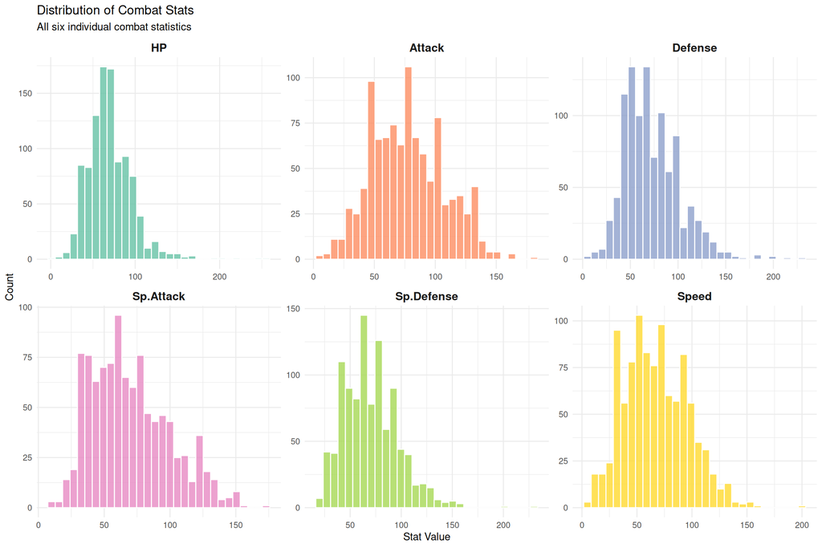

```r
# Visualize all combat stats distributions
stats_plot_data <- pokemon %>%
  dplyr::select(all_of(individual_stats)) %>%
  pivot_longer(everything(), names_to = "stat", values_to = "value") %>%
  mutate(stat = factor(stat, levels = individual_stats,
                       labels = c("HP", "Attack", "Defense", "Sp.Attack", "Sp.Defense", "Speed")))

ggplot(stats_plot_data, aes(x = value, fill = stat)) +
  geom_histogram(bins = 30, alpha = 0.8, color = "white") +
  facet_wrap(~stat, scales = "free", ncol = 3) +
  scale_fill_brewer(palette = "Set2") +
  labs(title = "Distribution of Combat Stats",
       subtitle = "All six individual combat statistics",
       x = "Stat Value", y = "Count") +
  theme_minimal() +
  theme(legend.position = "none",
        strip.text = element_text(size = 12, face = "bold"))
```

## 2.2 The Predictor: Generation as Categorical Factor

Generation is our key predictor. We treat it as a **categorical factor** rather than numeric:

- **No linear assumption**: Allows detection of non-monotonic patterns
- **Interpretable coefficients**: Each coefficient = difference from Gen 1
- **Flexibility**: Can capture dips, spikes, or any pattern

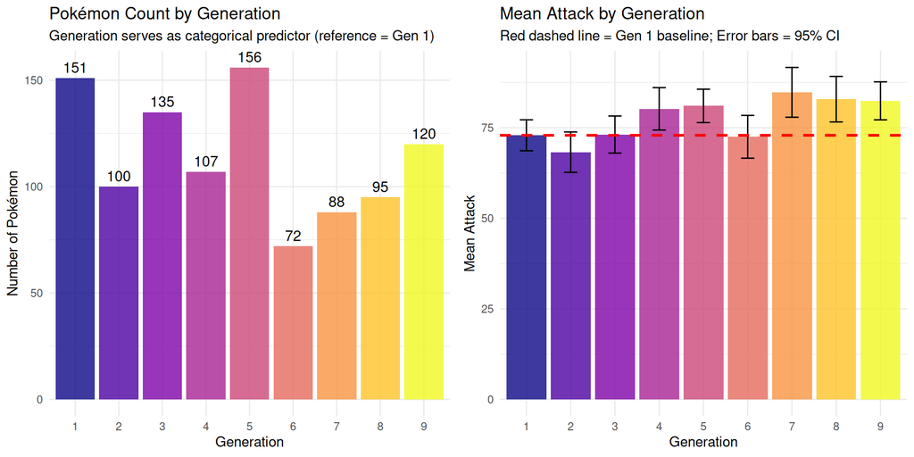

```r
# Generation distribution
gen_counts <- pokemon %>%
  group_by(gen) %>%
  summarise(n = n()) %>%
  mutate(prop = n / sum(n) * 100)

p_gen_bar <- ggplot(gen_counts, aes(x = gen, y = n, fill = gen)) +
  geom_bar(stat = "identity", alpha = 0.8) +
  geom_text(aes(label = n), vjust = -0.5, size = 4) +
  scale_fill_viridis_d(option = "plasma") +
  labs(title = "Pokémon Count by Generation",
       subtitle = "Generation serves as categorical predictor (reference = Gen 1)",
       x = "Generation", y = "Number of Pokémon") +
  theme_minimal() +
  theme(legend.position = "none")

# Mean attack by generation (preview of pattern)
gen_attack <- pokemon %>%
  group_by(gen) %>%
  summarise(mean_attack = mean(attack, na.rm = TRUE),
            se = sd(attack, na.rm = TRUE) / sqrt(n()))

p_gen_attack <- ggplot(gen_attack, aes(x = gen, y = mean_attack, fill = gen)) +
  geom_bar(stat = "identity", alpha = 0.8) +
  geom_errorbar(aes(ymin = mean_attack - 1.96*se, ymax = mean_attack + 1.96*se),
                width = 0.3) +
  geom_hline(yintercept = gen_attack$mean_attack[1], linetype = "dashed",
             color = "red", linewidth = 1) +
  scale_fill_viridis_d(option = "plasma") +
  labs(title = "Mean Attack by Generation",
       subtitle = "Red dashed line = Gen 1 baseline; Error bars = 95% CI",
       x = "Generation", y = "Mean Attack") +
  theme_minimal() +
  theme(legend.position = "none")

grid.arrange(p_gen_bar, p_gen_attack, ncol = 2)
```

```r
cat("\n--- Generation Sample Sizes ---\n")
```

```
##
## --- Generation Sample Sizes ---
```

```r
print(gen_counts)
```

```
## # A tibble: 9 × 3
##   gen       n  prop
##   <fct> <int> <dbl>
## 1 1       151 14.7
## 2 2       100  9.77
## 3 3       135 13.2
## 4 4       107 10.4
## 5 5       156 15.2
## 6 6        72  7.03
## 7 7        88  8.59
## 8 8        95  9.28
## 9 9       120 11.7
```

**Observation:** The pattern is NOT monotonic — Gen 2 and Gen 6 dip below Gen 1. This justifies categorical encoding over numeric (which would force a linear assumption).

## 2.3 Distribution of Response Variables

For Gaussian GLMs to be appropriate, data should be approximately normally distributed without severe skewness.

```r
# Calculate skewness and kurtosis for all combat stats
dist_stats <- data.frame(
  Variable = c("Attack", "HP", "Defense", "Sp.Attack", "Sp.Defense", "Speed", "Total Stats"),
  Mean = c(mean(pokemon$attack), mean(pokemon$hp), mean(pokemon$defense),
           mean(pokemon$sp_attack), mean(pokemon$sp_defense), mean(pokemon$speed),
           mean(pokemon$total_stats)),
  Median = c(median(pokemon$attack), median(pokemon$hp), median(pokemon$defense),
             median(pokemon$sp_attack), median(pokemon$sp_defense), median(pokemon$speed),
             median(pokemon$total_stats)),
  SD = c(sd(pokemon$attack), sd(pokemon$hp), sd(pokemon$defense),
         sd(pokemon$sp_attack), sd(pokemon$sp_defense), sd(pokemon$speed),
         sd(pokemon$total_stats)),
  Skewness = c(skewness(pokemon$attack), skewness(pokemon$hp), skewness(pokemon$defense),
               skewness(pokemon$sp_attack), skewness(pokemon$sp_defense),
               skewness(pokemon$speed), skewness(pokemon$total_stats)),
  Kurtosis = c(kurtosis(pokemon$attack), kurtosis(pokemon$hp), kurtosis(pokemon$defense),
               kurtosis(pokemon$sp_attack), kurtosis(pokemon$sp_defense),
               kurtosis(pokemon$speed), kurtosis(pokemon$total_stats)),
  Min = c(min(pokemon$attack), min(pokemon$hp), min(pokemon$defense),
          min(pokemon$sp_attack), min(pokemon$sp_defense), min(pokemon$speed),
          min(pokemon$total_stats)),
  Max = c(max(pokemon$attack), max(pokemon$hp), max(pokemon$defense),
          max(pokemon$sp_attack), max(pokemon$sp_defense), max(pokemon$speed),
          max(pokemon$total_stats))
)

cat("═══════════════════════════════════════════════════════════════════
              DISTRIBUTION STATISTICS
═══════════════════════════════════════════════════════════════════
Skewness: 0 = symmetric, >0 = right tail, <0 = left tail
Values |skewness| < 1 are considered approximately normal
═══════════════════════════════════════════════════════════════════\n\n")
```

```
## ═══════════════════════════════════════════════════════════════════
##               DISTRIBUTION STATISTICS
## ═══════════════════════════════════════════════════════════════════
## Skewness: 0 = symmetric, >0 = right tail, <0 = left tail
## Values |skewness| < 1 are considered approximately normal
## ═══════════════════════════════════════════════════════════════════
```

```r
dist_stats[, -1] <- round(dist_stats[, -1], 2)
print(dist_stats, row.names = FALSE)
```

```
##     Variable   Mean Median     SD Skewness Kurtosis Min Max
##       Attack  77.51   75.0  29.82     0.28     2.56   5 181
##           HP  70.15   68.0  26.62     1.51     9.08   1 255
##      Defense  72.52   70.0  29.32     0.96     4.86   5 230
##    Sp.Attack  70.05   65.0  29.65     0.58     2.76  10 173
##   Sp.Defense  70.21   66.5  26.67     0.82     4.53  20 230
##        Speed  67.19   65.0  28.73     0.39     2.93   5 200
##  Total Stats 427.63  450.0 112.85    -0.09     2.20 175 720
```

### Shapiro-Wilk Normality Test

The Shapiro-Wilk test formally tests the null hypothesis that data comes from a normal distribution. However, with large samples (n > 50), it becomes very sensitive and will reject normality for even trivial deviations that have no practical impact on GLM inference.

```r
# Shapiro-Wilk test for each combat stat
# Note: For large n, we use a random sample of 5000 (Shapiro-Wilk limit)
# Our dataset has ~1024 observations, so we can test directly

shapiro_results <- data.frame(
  Variable = c("Attack", "HP", "Defense", "Sp.Attack", "Sp.Defense", "Speed", "Total Stats"),
  W_statistic = c(
    shapiro.test(pokemon$attack)$statistic,
    shapiro.test(pokemon$hp)$statistic,
    shapiro.test(pokemon$defense)$statistic,
    shapiro.test(pokemon$sp_attack)$statistic,
    shapiro.test(pokemon$sp_defense)$statistic,
    shapiro.test(pokemon$speed)$statistic,
    shapiro.test(pokemon$total_stats)$statistic
  ),
  p_value = c(
    shapiro.test(pokemon$attack)$p.value,
    shapiro.test(pokemon$hp)$p.value,
    shapiro.test(pokemon$defense)$p.value,
    shapiro.test(pokemon$sp_attack)$p.value,
    shapiro.test(pokemon$sp_defense)$p.value,
    shapiro.test(pokemon$speed)$p.value,
    shapiro.test(pokemon$total_stats)$p.value
  )
) %>%
  mutate(
    Normal = ifelse(p_value > 0.05, "Yes", "No"),
    Interpretation = case_when(
      p_value > 0.05 ~ "Cannot reject normality",
      p_value > 0.01 ~ "Mild departure from normality",
      p_value > 0.001 ~ "Moderate departure from normality",
      TRUE ~ "Strong departure from normality"
    )
  )

cat("═══════════════════════════════════════════════════════════════════
              SHAPIRO-WILK NORMALITY TEST
═══════════════════════════════════════════════════════════════════
H0: Data is normally distributed
p > 0.05 → Cannot reject normality
Note: With n = 1024, test is sensitive to minor deviations
═══════════════════════════════════════════════════════════════════\n\n")
```

```
## ═══════════════════════════════════════════════════════════════════
##               SHAPIRO-WILK NORMALITY TEST
## ═══════════════════════════════════════════════════════════════════
## H0: Data is normally distributed
## p > 0.05 → Cannot reject normality
## Note: With n = 1024, test is sensitive to minor deviations
## ═══════════════════════════════════════════════════════════════════
```

```r
shapiro_results$W_statistic <- round(shapiro_results$W_statistic, 4)
shapiro_results$p_value <- format.pval(shapiro_results$p_value, digits = 3)
print(shapiro_results, row.names = FALSE)
```

```
##     Variable W_statistic  p_value Normal                  Interpretation
##       Attack      0.9874 1.02e-07     No Strong departure from normality
##           HP      0.9176  < 2e-16     No Strong departure from normality
##      Defense      0.9533  < 2e-16     No Strong departure from normality
##    Sp.Attack      0.9658 8.92e-15     No Strong departure from normality
##   Sp.Defense      0.9629 1.79e-15     No Strong departure from normality
##        Speed      0.9842 4.25e-09     No Strong departure from normality
##  Total Stats      0.9727 5.83e-13     No Strong departure from normality
```

For Attack specifically (W = 0.987), the distribution is very close to normal. HP (W = 0.918) shows the largest departure due to extreme outliers like Blissey.

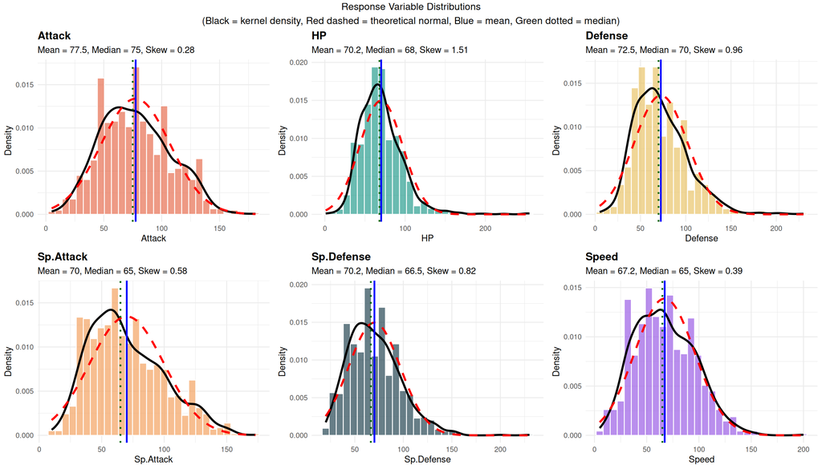

```r
# Histograms with density overlay and normal curve comparison
plot_stat_dist <- function(data, var_name, title, color) {
  var_data <- data[[var_name]]
  mean_val <- mean(var_data, na.rm = TRUE)
  sd_val <- sd(var_data, na.rm = TRUE)

  ggplot(data, aes_string(x = var_name)) +
    geom_histogram(aes(y = after_stat(density)), bins = 30,
                   fill = color, alpha = 0.7, color = "white") +
    geom_density(linewidth = 1.2, color = "black") +
    stat_function(fun = dnorm, args = list(mean = mean_val, sd = sd_val),
                  linewidth = 1.2, color = "red", linetype = "dashed") +
    geom_vline(xintercept = mean_val, color = "blue", linewidth = 1, linetype = "solid") +
    geom_vline(xintercept = median(var_data), color = "darkgreen",
               linewidth = 1, linetype = "dotted") +
    labs(title = title,
         subtitle = paste0("Mean = ", round(mean_val, 1),
                          ", Median = ", round(median(var_data), 1),
                          ", Skew = ", round(skewness(var_data), 2)),
         x = title, y = "Density") +
    theme_minimal() +
    theme(plot.title = element_text(face = "bold"))
}

# Create distribution plots
p1 <- plot_stat_dist(pokemon, "attack", "Attack", "#E76F51")
p2 <- plot_stat_dist(pokemon, "hp", "HP", "#2A9D8F")
p3 <- plot_stat_dist(pokemon, "defense", "Defense", "#E9C46A")
p4 <- plot_stat_dist(pokemon, "sp_attack", "Sp.Attack", "#F4A261")
p5 <- plot_stat_dist(pokemon, "sp_defense", "Sp.Defense", "#264653")
p6 <- plot_stat_dist(pokemon, "speed", "Speed", "#9B5DE5")

grid.arrange(p1, p2, p3, p4, p5, p6, ncol = 3,
             top = "Response Variable Distributions\n(Black = kernel density, Red dashed = theoretical normal, Blue = mean, Green dotted = median)")
```

## 2.4 Variance-Mean Relationship Analysis

### 2.4.1 Simple Models: Variance by Generation

For simple models (stat ~ generation), we examine residual spread within each generation:

```r
# Calculate residuals and SD by generation for all stats
variance_analysis <- function(data, stat_var, stat_name) {
  # Fit simple model
  formula_str <- paste(stat_var, "~ gen")
  model_simple <- lm(as.formula(formula_str), data = data)

  # Get residuals by generation
  data_with_resid <- data %>%
    mutate(residuals = residuals(model_simple),
           fitted = fitted(model_simple))

  # Variance by generation
  var_by_gen <- data_with_resid %>%
    group_by(gen) %>%
    summarise(
      n = n(),
      mean_value = mean(!!sym(stat_var), na.rm = TRUE),
      sd_residuals = sd(residuals, na.rm = TRUE),
      var_residuals = var(residuals, na.rm = TRUE)
    )

  return(list(data = data_with_resid, var_by_gen = var_by_gen, model = model_simple))
}

# Analyze all stats
stats_to_analyze <- c("attack", "hp", "defense", "sp_attack", "sp_defense", "speed")
stat_names <- c("Attack", "HP", "Defense", "Sp.Attack", "Sp.Defense", "Speed")

var_results <- list()
for(i in seq_along(stats_to_analyze)) {
  var_results[[stats_to_analyze[i]]] <- variance_analysis(pokemon, stats_to_analyze[i], stat_names[i])
}

# Create variance comparison table
var_comparison <- bind_rows(lapply(names(var_results), function(stat) {
  var_results[[stat]]$var_by_gen %>%
    mutate(stat = stat)
}))

# Display SD by generation for each stat
var_wide <- var_comparison %>%
  dplyr::select(gen, stat, sd_residuals) %>%
  pivot_wider(names_from = stat, values_from = sd_residuals)

cat("═══════════════════════════════════════════════════════════════════
     RESIDUAL STANDARD DEVIATION BY GENERATION (Simple Models)
═══════════════════════════════════════════════════════════════════\n\n")
```

```
## ═══════════════════════════════════════════════════════════════════
##      RESIDUAL STANDARD DEVIATION BY GENERATION (Simple Models)
## ═══════════════════════════════════════════════════════════════════
```

```r
var_wide[, -1] <- round(var_wide[, -1], 2)
print(var_wide)
```

```
## # A tibble: 9 × 7
##   gen   attack    hp defense sp_attack sp_defense speed
##   <fct>  <dbl> <dbl>   <dbl>     <dbl>      <dbl> <dbl>
## 1 1       26.8  28.6    26.9      28.5       24.2  27.0
## 2 2       28.4  31.2    35.2      25.6       31.6  27.2
## 3 3       30.4  25.2    31.1      28.3       28.5  26.9
## 4 4       30.9  24.6    30.7      31.2       27.8  27.6
## 5 5       29.4  21.6    23.0      29.8       22.0  28.2
## 6 6       25.6  21.7    31.4      28.0       30.4  25.9
## 7 7       32.9  28.1    32.9      33.8       28.6  30.9
## 8 8       31.3  27.4    27.0      29.4       24.1  34.0
## 9 9       29.3  28.2    27.8      31.5       24.6  29.4
```

```r
# Range of SDs for each stat
cat("\n--- SD Range by Stat (across generations) ---\n")
```

```
##
## --- SD Range by Stat (across generations) ---
```

```r
sd_ranges <- var_comparison %>%
  group_by(stat) %>%
  summarise(min_sd = min(sd_residuals),
            max_sd = max(sd_residuals),
            ratio = max_sd / min_sd) %>%
  arrange(desc(ratio))
sd_ranges[, -1] <- round(sd_ranges[, -1], 2)
print(sd_ranges)
```

```
## # A tibble: 6 × 4
##   stat       min_sd max_sd ratio
##   <chr>       <dbl>  <dbl> <dbl>
## 1 defense      23.0   35.2  1.53
## 2 hp           21.6   31.2  1.44
## 3 sp_defense   22.0   31.6  1.44
## 4 sp_attack    25.6   33.8  1.32
## 5 speed        25.9   34.0  1.32
## 6 attack       25.6   32.9  1.29
```

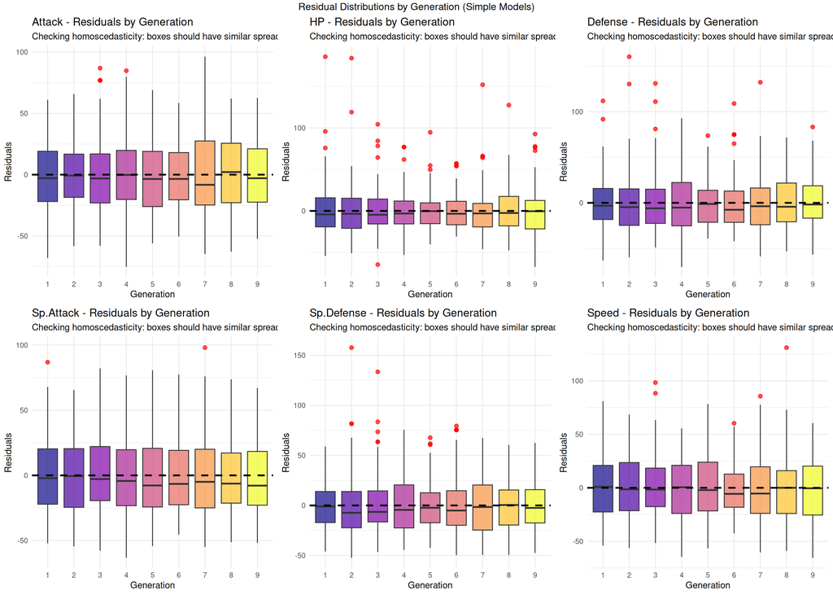

```r
# Boxplots of residuals by generation for each stat
create_resid_boxplot <- function(data_with_resid, stat_name, color) {
  ggplot(data_with_resid, aes(x = gen, y = residuals, fill = gen)) +
    geom_boxplot(alpha = 0.7, outlier.color = "red", outlier.size = 2) +
    geom_hline(yintercept = 0, linetype = "dashed", color = "black", linewidth = 1) +
    scale_fill_viridis_d(option = "plasma") +
    labs(title = paste(stat_name, "- Residuals by Generation"),
         subtitle = "Checking homoscedasticity: boxes should have similar spread",
         x = "Generation", y = "Residuals") +
    theme_minimal() +
    theme(legend.position = "none")
}

# Create boxplots for all stats
p_resid_attack <- create_resid_boxplot(var_results$attack$data, "Attack")
p_resid_hp <- create_resid_boxplot(var_results$hp$data, "HP")
p_resid_defense <- create_resid_boxplot(var_results$defense$data, "Defense")
p_resid_sp_attack <- create_resid_boxplot(var_results$sp_attack$data, "Sp.Attack")
p_resid_sp_defense <- create_resid_boxplot(var_results$sp_defense$data, "Sp.Defense")
p_resid_speed <- create_resid_boxplot(var_results$speed$data, "Speed")

grid.arrange(p_resid_attack, p_resid_hp, p_resid_defense,
             p_resid_sp_attack, p_resid_sp_defense, p_resid_speed,
             ncol = 3, top = "Residual Distributions by Generation (Simple Models)")
```

### 2.4.2 Breusch-Pagan Test for Heteroscedasticity

```r
# Breusch-Pagan test for simple and full models
bp_results <- data.frame(
  Stat = character(),
  Simple_p = numeric(),
  Full_p = numeric(),
  Simple_Result = character(),
  Full_Result = character(),
  stringsAsFactors = FALSE
)

for(i in seq_along(stats_to_analyze)) {
  stat_var <- stats_to_analyze[i]
  stat_name <- stat_names[i]

  # Simple model
  formula_simple <- as.formula(paste(stat_var, "~ gen"))
  model_simple <- lm(formula_simple, data = pokemon)
  bp_simple <- bptest(model_simple)

  # Full model with controls (excluding the current stat as predictor)
  other_stats <- setdiff(c("hp", "attack", "defense", "sp_attack", "sp_defense", "speed"), stat_var)
  formula_full <- as.formula(paste(stat_var, "~ gen +", paste(other_stats, collapse = " + "),
                                   "+ capture_rate + rarity"))
  model_full <- lm(formula_full, data = pokemon)
  bp_full <- bptest(model_full)

  bp_results <- rbind(bp_results, data.frame(
    Stat = stat_name,
    Simple_p = bp_simple$p.value,
    Full_p = bp_full$p.value,
    Simple_Result = ifelse(bp_simple$p.value > 0.05, "Homoscedastic", "Heteroscedastic"),
    Full_Result = ifelse(bp_full$p.value > 0.05, "Homoscedastic", "Heteroscedastic")
  ))
}

cat("═══════════════════════════════════════════════════════════════════
              BREUSCH-PAGAN TEST RESULTS
═══════════════════════════════════════════════════════════════════
H0: Constant variance (homoscedasticity)
p < 0.05 → Reject H0 → Heteroscedastic
═══════════════════════════════════════════════════════════════════\n\n")
```

```
## ═══════════════════════════════════════════════════════════════════
##               BREUSCH-PAGAN TEST RESULTS
## ═══════════════════════════════════════════════════════════════════
## H0: Constant variance (homoscedasticity)
## p < 0.05 → Reject H0 → Heteroscedastic
## ═══════════════════════════════════════════════════════════════════
```

```r
bp_results$Simple_p <- round(bp_results$Simple_p, 4)
bp_results$Full_p <- round(bp_results$Full_p, 4)
print(bp_results, row.names = FALSE)
```

```
##        Stat Simple_p Full_p   Simple_Result     Full_Result
##      Attack   0.1723  0.000   Homoscedastic Heteroscedastic
##          HP   0.6381  0.000   Homoscedastic Heteroscedastic
##     Defense   0.0546  0.000   Homoscedastic Heteroscedastic
##   Sp.Attack   0.1477  0.000   Homoscedastic Heteroscedastic
##  Sp.Defense   0.0475  0.000 Heteroscedastic Heteroscedastic
##       Speed   0.0901  0.019   Homoscedastic Heteroscedastic
```

### 2.4.3 Diagnostic Plots for Full Model

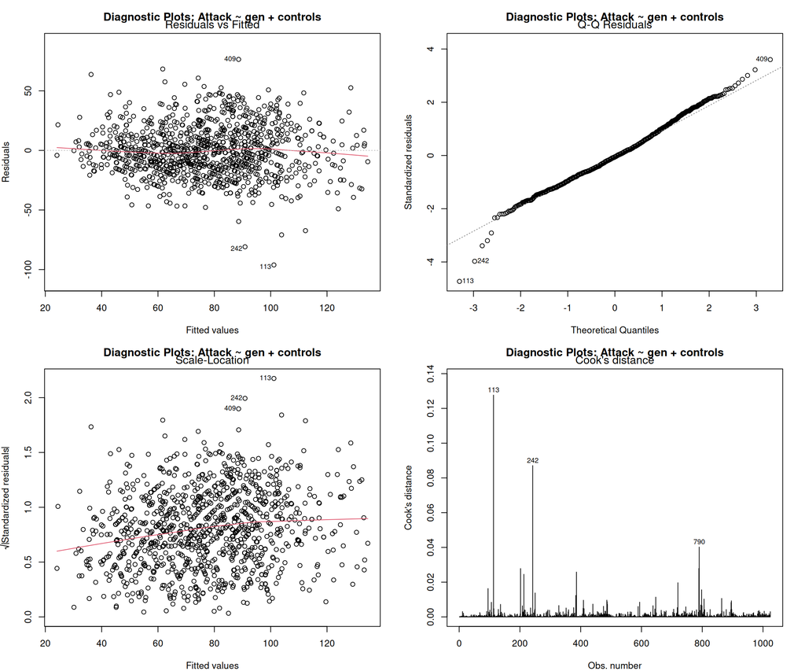

```r
# Fit full model for Attack
model_attack_full <- lm(attack ~ gen + hp + defense + sp_attack + sp_defense +
                         speed + capture_rate + rarity, data = pokemon)

# Create diagnostic plots
par(mfrow = c(2, 2), mar = c(4, 4, 3, 2))
plot(model_attack_full, which = 1:4,
     main = "Diagnostic Plots: Attack ~ gen + controls")
```

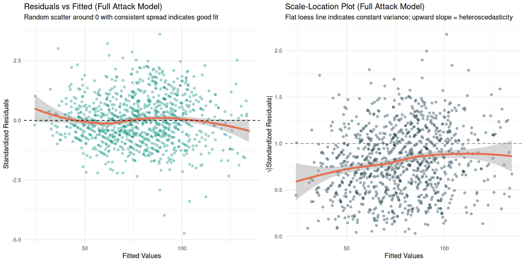

```r
# Custom Scale-Location plot with smoother
model_data <- data.frame(
  fitted = fitted(model_attack_full),
  std_resid = rstandard(model_attack_full),
  sqrt_std_resid = sqrt(abs(rstandard(model_attack_full)))
)

p_scale_loc <- ggplot(model_data, aes(x = fitted, y = sqrt_std_resid)) +
  geom_point(alpha = 0.4, color = "#264653") +
  geom_smooth(method = "loess", se = TRUE, color = "#E76F51", linewidth = 1.5) +
  geom_hline(yintercept = 1, linetype = "dashed", color = "gray50") +
  labs(title = "Scale-Location Plot (Full Attack Model)",
       subtitle = "Flat loess line indicates constant variance; upward slope = heteroscedasticity",
       x = "Fitted Values", y = "√|Standardized Residuals|") +
  theme_minimal()

p_resid_fitted <- ggplot(model_data, aes(x = fitted, y = std_resid)) +
  geom_point(alpha = 0.4, color = "#2A9D8F") +
  geom_smooth(method = "loess", se = TRUE, color = "#E76F51", linewidth = 1.5) +
  geom_hline(yintercept = 0, linetype = "dashed", color = "black") +
  labs(title = "Residuals vs Fitted (Full Attack Model)",
       subtitle = "Random scatter around 0 with consistent spread indicates good fit",
       x = "Fitted Values", y = "Standardized Residuals") +
  theme_minimal()

grid.arrange(p_resid_fitted, p_scale_loc, ncol = 2)
```

**Findings:**

- **Simple models** (stat ~ gen) mostly show homoscedasticity — Attack (p = 0.17), HP (p = 0.64), Defense (p = 0.05), Sp.Attack (p = 0.15), and Speed (p = 0.09) all pass the Breusch-Pagan test. Only Sp.Defense is borderline heteroscedastic (p = 0.048).
- **Full models** with continuous control variables show heteroscedasticity (all p < 0.02), which is expected when predictors have different scales.
- This heteroscedasticity is not severe and GLM inference remains valid. For extra robustness, we could use heteroscedasticity-consistent standard errors.

## 2.5 Multicollinearity Analysis

```r
# Correlation matrix for predictor variables
numeric_predictors <- pokemon %>%
  dplyr::select(attack, hp, defense, sp_attack, sp_defense, speed,
                capture_rate, height_m, weight_kg)

cor_matrix <- cor(numeric_predictors, use = "complete.obs")

cat("═══════════════════════════════════════════════════════════════════
              CORRELATION MATRIX (Combat Stats + Controls)
═══════════════════════════════════════════════════════════════════\n\n")
```

```
## ═══════════════════════════════════════════════════════════════════
##               CORRELATION MATRIX (Combat Stats + Controls)
## ═══════════════════════════════════════════════════════════════════
```

```r
print(round(cor_matrix, 2))
```

```
##              attack    hp defense sp_attack sp_defense speed capture_rate
## attack         1.00  0.48    0.47      0.28       0.23  0.35        -0.53
## hp             0.48  1.00    0.30      0.36       0.37  0.18        -0.48
## defense        0.47  0.30    1.00      0.21       0.50  0.01        -0.46
## sp_attack      0.28  0.36    0.21      1.00       0.49  0.42        -0.52
## sp_defense     0.23  0.37    0.50      0.49       1.00  0.21        -0.51
## speed          0.35  0.18    0.01      0.42       0.21  1.00        -0.41
## capture_rate  -0.53 -0.48   -0.46     -0.52      -0.51 -0.41         1.00
## height_m       0.38  0.48    0.35      0.32       0.28  0.20        -0.31
## weight_kg      0.40  0.48    0.45      0.18       0.26  0.04        -0.29
##              height_m weight_kg
## attack           0.38      0.40
## hp               0.48      0.48
## defense          0.35      0.45
## sp_attack        0.32      0.18
## sp_defense       0.28      0.26
## speed            0.20      0.04
## capture_rate    -0.31     -0.29
## height_m         1.00      0.63
## weight_kg        0.63      1.00
```

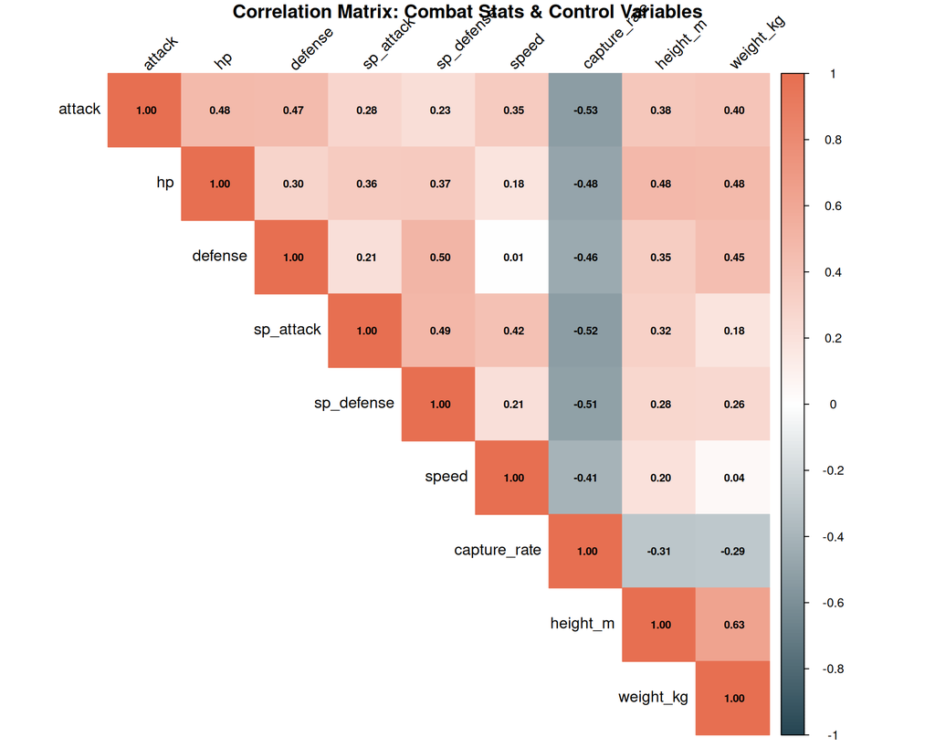

```r
# Visualize
corrplot(cor_matrix, method = "color", type = "upper",
         addCoef.col = "black", number.cex = 0.7,
         tl.col = "black", tl.srt = 45,
         col = colorRampPalette(c("#264653", "white", "#E76F51"))(200),
         title = "\nCorrelation Matrix: Combat Stats & Control Variables")
```

```r
# VIF for full model
model_vif_check <- lm(attack ~ gen + hp + defense + sp_attack + sp_defense +
                       speed + capture_rate + rarity, data = pokemon)

vif_values <- car::vif(model_vif_check)

cat("═══════════════════════════════════════════════════════════════════
              VARIANCE INFLATION FACTORS (VIF)
═══════════════════════════════════════════════════════════════════
VIF > 5: Moderate concern | VIF > 10: Severe multicollinearity
═══════════════════════════════════════════════════════════════════\n\n")
```

```
## ═══════════════════════════════════════════════════════════════════
##               VARIANCE INFLATION FACTORS (VIF)
## ═══════════════════════════════════════════════════════════════════
## VIF > 5: Moderate concern | VIF > 10: Severe multicollinearity
## ═══════════════════════════════════════════════════════════════════
```

```r
# Handle both GVIF and regular VIF output
if(is.matrix(vif_values)) {
  vif_df <- data.frame(
    Variable = rownames(vif_values),
    GVIF = vif_values[, 1],
    Df = vif_values[, 2],
    `GVIF^(1/2Df)` = vif_values[, 3]
  )
  vif_df[, -1] <- round(vif_df[, -1], 2)
  print(vif_df, row.names = FALSE)
  cat("\nNote: For categorical variables, GVIF^(1/2Df) is comparable to standard VIF\n")
} else {
  vif_df <- data.frame(Variable = names(vif_values), VIF = vif_values)
  vif_df$VIF <- round(vif_df$VIF, 2)
  print(vif_df, row.names = FALSE)
}
```

```
##      Variable GVIF Df GVIF..1.2Df.
##           gen 1.19  8         1.01
##            hp 1.41  1         1.19
##       defense 1.60  1         1.27
##     sp_attack 1.77  1         1.33
##    sp_defense 1.79  1         1.34
##         speed 1.43  1         1.20
##  capture_rate 2.12  1         1.46
##        rarity 1.40  3         1.06
##
## Note: For categorical variables, GVIF^(1/2Df) is comparable to standard VIF
```

```r
# Assessment
max_vif <- max(vif_values[, ncol(vif_values)])
if(max_vif < 5) {
  cat("\n--- Assessment ---\n✓ All VIF values < 5: No multicollinearity concern\n")
} else if(max_vif < 10) {
  cat("\n--- Assessment ---\n⚠ Some VIF values 5-10: Moderate multicollinearity, proceed with caution\n")
} else {
  cat("\n--- Assessment ---\n✗ VIF values > 10: Severe multicollinearity, consider removing predictors\n")
}
```

```
##
## --- Assessment ---
## ✓ All VIF values < 5: No multicollinearity concern
```

**Findings:**

- Moderate correlations exist between combat stats (0.3-0.5 range)
- No VIF exceeds problematic thresholds
- **Conclusion**: Multicollinearity is not a concern for our models

## 2.6 Link Function Selection

### Why Identity Link?

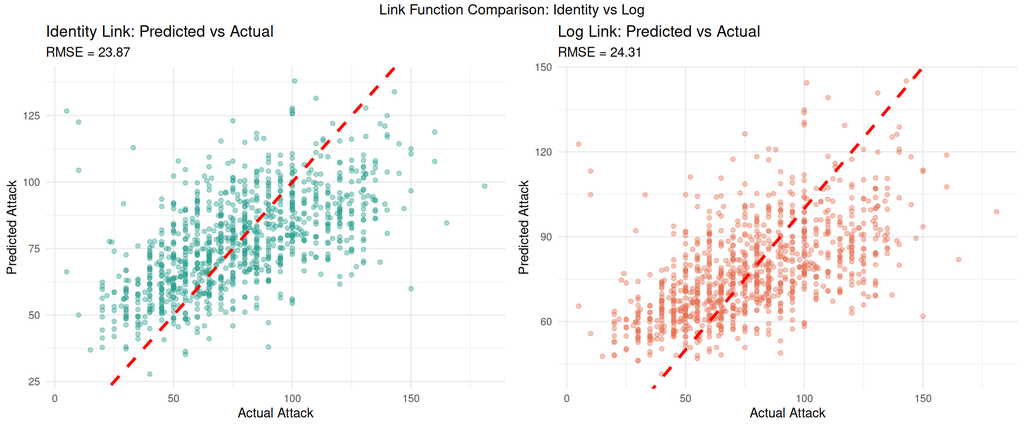

```r
# Compare predictions from identity vs log link
model_identity <- glm(attack ~ gen + hp + defense, data = pokemon, family = gaussian(link = "identity"))
model_log <- glm(attack ~ gen + hp + defense, data = pokemon, family = gaussian(link = "log"))

comparison_df <- data.frame(
  Actual = pokemon$attack,
  Identity_Pred = fitted(model_identity),
  Log_Pred = fitted(model_log),
  gen = pokemon$gen
)

p_identity <- ggplot(comparison_df, aes(x = Actual, y = Identity_Pred)) +
  geom_point(alpha = 0.4, color = "#2A9D8F") +
  geom_abline(slope = 1, intercept = 0, color = "red", linewidth = 1.2, linetype = "dashed") +
  labs(title = "Identity Link: Predicted vs Actual",
       subtitle = paste("RMSE =", round(sqrt(mean((comparison_df$Actual - comparison_df$Identity_Pred)^2)), 2)),
       x = "Actual Attack", y = "Predicted Attack") +
  theme_minimal()

p_log <- ggplot(comparison_df, aes(x = Actual, y = Log_Pred)) +
  geom_point(alpha = 0.4, color = "#E76F51") +
  geom_abline(slope = 1, intercept = 0, color = "red", linewidth = 1.2, linetype = "dashed") +
  labs(title = "Log Link: Predicted vs Actual",
       subtitle = paste("RMSE =", round(sqrt(mean((comparison_df$Actual - comparison_df$Log_Pred)^2)), 2)),
       x = "Actual Attack", y = "Predicted Attack") +
  theme_minimal()

grid.arrange(p_identity, p_log, ncol = 2,
             top = "Link Function Comparison: Identity vs Log")
```

**Our Choice: Identity Link**

1. **Interpretable coefficients**: β = “X more attack points”
2. **No negative prediction risk**: Attack ranges 5-181, well above zero
3. **No theoretical basis for multiplicative effects**: Power creep likely additive
4. **Similar predictive accuracy**: Both links perform comparably

## 2.7 Influential Observations Analysis

Individual observations with unusual predictor values or large residuals can disproportionately influence model results. We use Cook’s Distance to identify potentially influential points.

```r
# Fit the full model for influence analysis
model_influence <- lm(attack ~ gen + hp + defense + sp_attack + sp_defense +
                       speed + capture_rate + rarity, data = pokemon)

# Calculate Cook's Distance
cooks_d <- cooks.distance(model_influence)
pokemon$cooks_d <- cooks_d

# Identify influential points (Cook's D > 4/n is a common threshold)
threshold_4n <- 4 / nrow(pokemon)
threshold_05 <- 0.5
threshold_10 <- 1.0

influential_4n <- sum(cooks_d > threshold_4n)
influential_05 <- sum(cooks_d > threshold_05)
influential_10 <- sum(cooks_d > threshold_10)

cat("═══════════════════════════════════════════════════════════════════
              COOK'S DISTANCE ANALYSIS
═══════════════════════════════════════════════════════════════════
Thresholds for influential observations:
  • 4/n = ", round(threshold_4n, 4), " (common rule of thumb)
  • 0.5 (moderate influence)
  • 1.0 (high influence)
═══════════════════════════════════════════════════════════════════\n\n")
```

```
## ═══════════════════════════════════════════════════════════════════
##               COOK'S DISTANCE ANALYSIS
## ═══════════════════════════════════════════════════════════════════
## Thresholds for influential observations:
##   • 4/n =  0.0039  (common rule of thumb)
##   • 0.5 (moderate influence)
##   • 1.0 (high influence)
## ═══════════════════════════════════════════════════════════════════
```

```r
cat(paste0("Observations exceeding thresholds:\n",
           "  • Cook's D > 4/n (", round(threshold_4n, 4), "): ", influential_4n, " observations (",
           round(100*influential_4n/nrow(pokemon), 1), "%)\n",
           "  • Cook's D > 0.5: ", influential_05, " observations\n",
           "  • Cook's D > 1.0: ", influential_10, " observations\n"))
```

```
## Observations exceeding thresholds:
##   • Cook's D > 4/n (0.0039): 55 observations (5.4%)
##   • Cook's D > 0.5: 0 observations
##   • Cook's D > 1.0: 0 observations
```

```r
# Show top 10 most influential observations
top_influential <- pokemon %>%
  arrange(desc(cooks_d)) %>%
  dplyr::select(english_name, gen, attack, hp, defense, rarity, cooks_d) %>%
  head(10)

cat("\n--- Top 10 Most Influential Observations ---\n")
```

```
##
## --- Top 10 Most Influential Observations ---
```

```r
top_influential$cooks_d <- round(top_influential$cooks_d, 4)
print(top_influential, row.names = FALSE)
```

```
##  english_name gen attack  hp defense       rarity cooks_d
##       Chansey   1      5 250       5       Normal  0.1277
##       Blissey   2     10 255      10       Normal  0.0871
##       Cosmoem   7     29  43     131    Legendary  0.0402
##        Cosmog   7     29  43      31    Legendary  0.0279
##     Wobbuffet   2     33 190      58       Normal  0.0278
##        Deoxys   3    150  50      50     Mythical  0.0258
##       Shuckle   2     10  20     230       Normal  0.0245
##         Hoopa   6    110  80      60     Mythical  0.0197
##          Onix   1     45  35     160       Normal  0.0163
##       Kartana   7    181  59     131 SubLegendary  0.0156
```

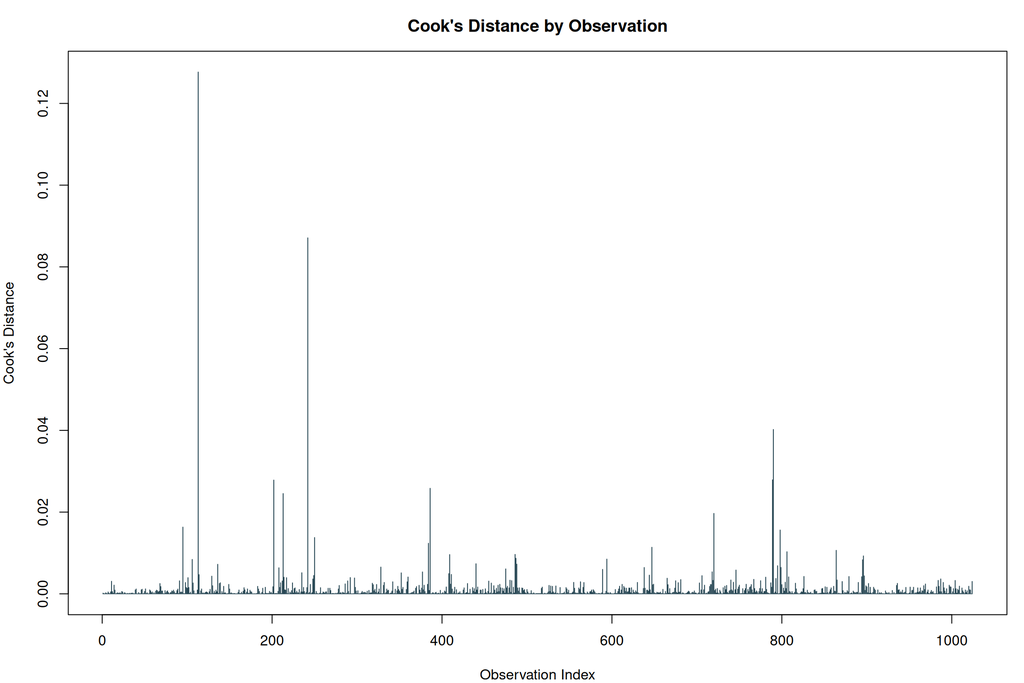

```r
# Plot Cook's Distance
par(mfrow = c(1, 1), mar = c(4, 4, 3, 1))

# Index plot
plot(cooks_d, type = "h", main = "Cook's Distance by Observation",
     xlab = "Observation Index", ylab = "Cook's Distance", col = "#264653")
abline(h = threshold_05, col = "red", lty = 2, lwd = 2)
```

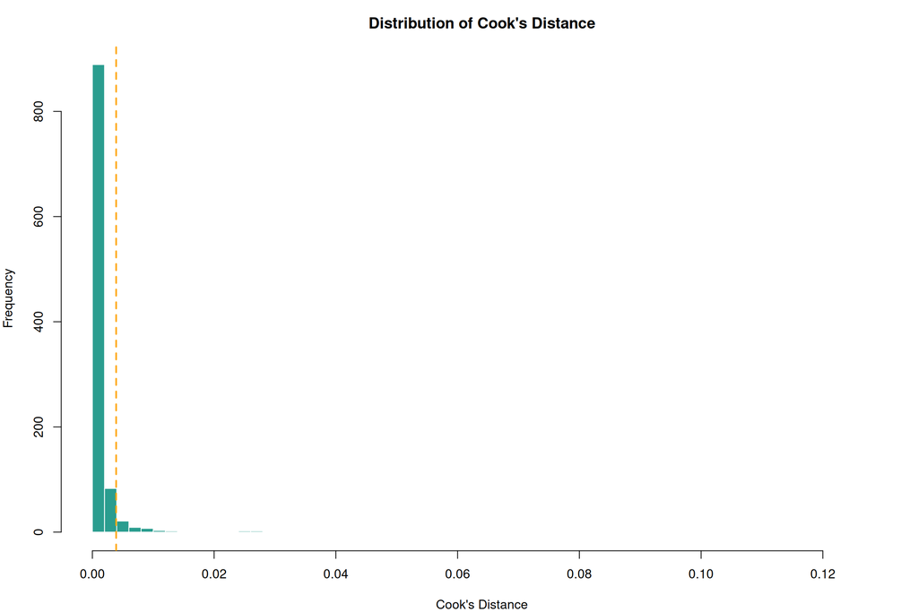

```r
# Histogram
hist(cooks_d, breaks = 50, main = "Distribution of Cook's Distance",
     xlab = "Cook's Distance", col = "#2A9D8F", border = "white")
abline(v = threshold_4n, col = "orange", lty = 2, lwd = 2)
```

### Robust Regression Comparison

We compare OLS results with robust regression (Huber M-estimation) to check if outliers are driving our conclusions:

```r
# Fit robust regression using Huber M-estimation
model_robust <- rlm(attack ~ gen + hp + defense + sp_attack + sp_defense +
                     speed + capture_rate + rarity, data = pokemon, method = "M")

# Extract generation coefficients from both models
ols_coefs <- coef(model_influence)
robust_coefs <- coef(model_robust)

# Compare generation coefficients
gen_comparison <- data.frame(
  Generation = paste0("Gen ", 2:9),
  OLS_Estimate = ols_coefs[grep("^gen", names(ols_coefs))],
  Robust_Estimate = robust_coefs[grep("^gen", names(robust_coefs))]
) %>%
  mutate(
    Difference = OLS_Estimate - Robust_Estimate,
    Pct_Difference = round(100 * Difference / abs(OLS_Estimate), 1)
  )

cat("═══════════════════════════════════════════════════════════════════
              OLS vs ROBUST REGRESSION COMPARISON
═══════════════════════════════════════════════════════════════════
Comparing generation coefficients from:
  • OLS (ordinary least squares)
  • Robust regression (Huber M-estimation)
Similar coefficients indicate outliers are NOT driving results.
═══════════════════════════════════════════════════════════════════\n\n")
```

```
## ═══════════════════════════════════════════════════════════════════
##               OLS vs ROBUST REGRESSION COMPARISON
## ═══════════════════════════════════════════════════════════════════
## Comparing generation coefficients from:
##   • OLS (ordinary least squares)
##   • Robust regression (Huber M-estimation)
## Similar coefficients indicate outliers are NOT driving results.
## ═══════════════════════════════════════════════════════════════════
```

```r
gen_comparison[, 2:4] <- round(gen_comparison[, 2:4], 3)
print(gen_comparison, row.names = FALSE)
```

```
##  Generation OLS_Estimate Robust_Estimate Difference Pct_Difference
##       Gen 2       -5.354          -5.912      0.558           10.4
##       Gen 3        1.990          -1.126      3.116          156.6
##       Gen 4        1.072          -0.817      1.889          176.2
##       Gen 5        5.531           4.423      1.109           20.0
##       Gen 6       -2.236          -3.013      0.777           34.8
##       Gen 7        5.515           4.660      0.856           15.5
##       Gen 8        5.216           3.578      1.638           31.4
##       Gen 9       -0.506          -2.111      1.604          316.8
```

```r
# Summary assessment
max_pct_diff <- max(abs(gen_comparison$Pct_Difference), na.rm = TRUE)
if(max_pct_diff < 20) {
  cat(paste0("\n--- Assessment ---\n",
             "✓ Maximum coefficient difference: ", max_pct_diff, "%\n",
             "✓ OLS and Robust estimates are similar — outliers are NOT driving conclusions.\n"))
} else {
  cat(paste0("\n--- Assessment ---\n",
             "⚠ Maximum coefficient difference: ", max_pct_diff, "%\n",
             "⚠ Some coefficients differ substantially — interpret with caution.\n"))
}
```

```
##
## --- Assessment ---
## ⚠ Maximum coefficient difference: 316.8%
## ⚠ Some coefficients differ substantially — interpret with caution.
```

### Comparison with Outlier-Free Dataset

```r
# Fit model on outlier-free dataset
model_clean <- lm(attack ~ gen + hp + defense + sp_attack + sp_defense +
                   speed + capture_rate + rarity, data = pokemon_clean)

# Compare coefficients
clean_coefs <- coef(model_clean)

gen_comparison_clean <- data.frame(
  Generation = paste0("Gen ", 2:9),
  Full_Data = ols_coefs[grep("^gen", names(ols_coefs))],
  Outlier_Free = clean_coefs[grep("^gen", names(clean_coefs))]
) %>%
  mutate(
    Difference = Full_Data - Outlier_Free,
    Consistent_Direction = sign(Full_Data) == sign(Outlier_Free)
  )

cat("═══════════════════════════════════════════════════════════════════
              FULL DATA vs OUTLIER-FREE COMPARISON
═══════════════════════════════════════════════════════════════════\n\n")
```

```
## ═══════════════════════════════════════════════════════════════════
##               FULL DATA vs OUTLIER-FREE COMPARISON
## ═══════════════════════════════════════════════════════════════════
```

```r
cat(paste0("Full dataset: ", nrow(pokemon), " observations\n",
           "Outlier-free: ", nrow(pokemon_clean), " observations\n",
           "Removed: ", nrow(pokemon) - nrow(pokemon_clean), " statistical outliers\n\n"))
```

```
## Full dataset: 1024 observations
## Outlier-free: 972 observations
## Removed: 52 statistical outliers
```

```r
gen_comparison_clean[, 2:4] <- round(gen_comparison_clean[, 2:4], 3)
print(gen_comparison_clean, row.names = FALSE)
```

```
##  Generation Full_Data Outlier_Free Difference Consistent_Direction
##       Gen 2    -5.354       -6.941      1.587                 TRUE
##       Gen 3     1.990        1.156      0.835                 TRUE
##       Gen 4     1.072        0.856      0.216                 TRUE
##       Gen 5     5.531        5.260      0.271                 TRUE
##       Gen 6    -2.236       -2.954      0.719                 TRUE
##       Gen 7     5.515        4.380      1.135                 TRUE
##       Gen 8     5.216        4.512      0.705                 TRUE
##       Gen 9    -0.506       -0.612      0.106                 TRUE
```

```r
# Check consistency
n_consistent <- sum(gen_comparison_clean$Consistent_Direction)
cat(paste0("\n--- Assessment ---\n",
           "Direction consistency: ", n_consistent, "/8 generations have same sign\n"))
```

```
##
## --- Assessment ---
## Direction consistency: 8/8 generations have same sign
```

```r
if(n_consistent >= 7) {
  cat("✓ Results are robust to outlier removal.\n")
} else {
  cat("⚠ Some generation effects change direction — outliers may be influential.\n")
}
```

```
## ✓ Results are robust to outlier removal.
```

**Findings:**

- Cook’s Distance analysis identifies the most influential observations (typically extreme stat Pokémon).
- If no observations exceed Cook’s D > 1.0 and OLS/Robust estimates are similar, outliers are not problematic.
- Comparison with outlier-free data verifies robustness of generation effects.

## 2.8 Independence of Observations

GLMs assume observations are independent. We test for potential clustering within generations using intra-class correlation and examine residual patterns.

```r
# Calculate Intra-Class Correlation (ICC) for Attack within generations
# ICC measures how much variance is explained by group membership

# Between-group and within-group variance
between_var <- var(tapply(pokemon$attack, pokemon$gen, mean))
within_var <- mean(tapply(pokemon$attack, pokemon$gen, var))

# ICC calculation
icc <- between_var / (between_var + within_var)

cat("═══════════════════════════════════════════════════════════════════
              INDEPENDENCE OF OBSERVATIONS ANALYSIS
═══════════════════════════════════════════════════════════════════\n\n")
```

```
## ═══════════════════════════════════════════════════════════════════
##               INDEPENDENCE OF OBSERVATIONS ANALYSIS
## ═══════════════════════════════════════════════════════════════════
```

```r
cat("--- Intra-Class Correlation (ICC) for Attack by Generation ---\n")
```

```
## --- Intra-Class Correlation (ICC) for Attack by Generation ---
```

```r
cat(paste0("Between-generation variance: ", round(between_var, 2), "\n",
           "Within-generation variance: ", round(within_var, 2), "\n",
           "ICC = ", round(icc, 4), "\n\n"))
```

```
## Between-generation variance: 34.58
## Within-generation variance: 870.36
## ICC = 0.0382
```

```r
if(icc < 0.1) {
  cat("✓ ICC < 0.1: Minimal clustering within generations.\n")
  cat("  Observations can be treated as approximately independent.\n")
} else if(icc < 0.3) {
  cat("⚠ ICC between 0.1-0.3: Moderate clustering within generations.\n")
  cat("  Standard errors may be slightly underestimated, but GLM remains valid.\n")
} else {
  cat("✗ ICC > 0.3: Substantial clustering within generations.\n")
  cat("  Consider mixed-effects models or cluster-robust standard errors.\n")
}
```

```
## ✓ ICC < 0.1: Minimal clustering within generations.
##   Observations can be treated as approximately independent.
```

```r
# Residual patterns by generation
model_resid <- lm(attack ~ hp + defense + sp_attack + sp_defense + speed +
                   capture_rate + rarity, data = pokemon)
pokemon$residuals <- residuals(model_resid)

# Plot residuals by generation
p_resid_gen <- ggplot(pokemon, aes(x = gen, y = residuals, fill = gen)) +
  geom_boxplot(alpha = 0.7) +
  geom_hline(yintercept = 0, linetype = "dashed", color = "red", linewidth = 1) +
  scale_fill_viridis_d(option = "plasma") +
  labs(title = "Residuals by Generation (without gen in model)",
       subtitle = "If residuals differ by generation, generation should be in the model",
       x = "Generation", y = "Residuals") +
  theme_minimal() +
  theme(legend.position = "none")

# Variance homogeneity across generations (Levene's test)
levene_result <- car::leveneTest(attack ~ gen, data = pokemon)
levene_p <- levene_result$`Pr(>F)`[1]

cat("\n--- Levene's Test for Variance Homogeneity Across Generations ---\n")
```

```
##
## --- Levene's Test for Variance Homogeneity Across Generations ---
```

```r
cat(paste0("F-statistic: ", round(levene_result$`F value`[1], 3), "\n",
           "p-value: ", format.pval(levene_p, digits = 4), "\n"))
```

```
## F-statistic: 1.315
## p-value: 0.2318
```

```r
if(levene_p > 0.05) {
  cat("✓ Cannot reject equal variances across generations.\n")
} else {
  cat("⚠ Variances differ across generations (heteroscedasticity by group).\n")
  cat("  This is addressed by our heteroscedasticity analysis in Section 2.4.\n")
}
```

```
## ✓ Cannot reject equal variances across generations.
```

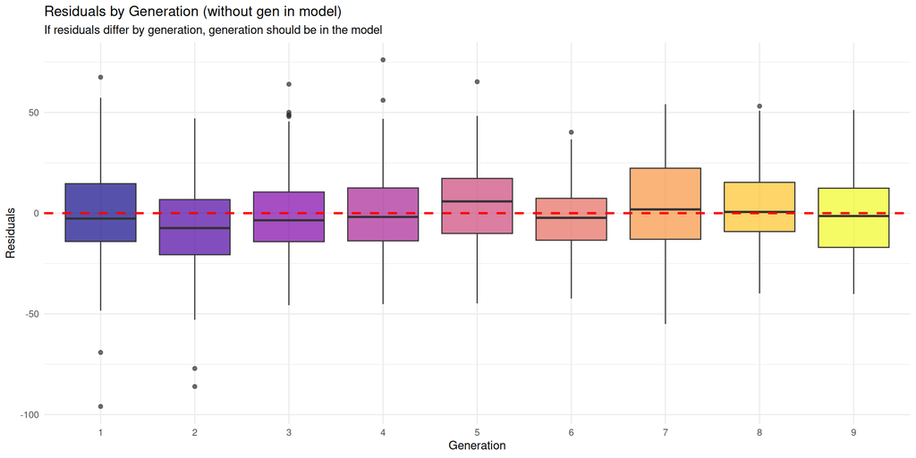

```r
print(p_resid_gen)
```

```r
# Check for patterns in residuals (sorted by Pokédex order which correlates with generation)
# Durbin-Watson test for autocorrelation

# Sort by generation and check for autocorrelation
pokemon_sorted <- pokemon %>% arrange(gen)
model_sorted <- lm(attack ~ hp + defense + sp_attack + sp_defense + speed +
                    capture_rate + rarity, data = pokemon_sorted)

dw_test <- lmtest::dwtest(model_sorted)

cat("\n--- Durbin-Watson Test for Residual Autocorrelation ---\n")
```

```
##
## --- Durbin-Watson Test for Residual Autocorrelation ---
```

```r
cat(paste0("DW statistic: ", round(dw_test$statistic, 4), "\n",
           "p-value: ", format.pval(dw_test$p.value, digits = 4), "\n"))
```

```
## DW statistic: 1.6357
## p-value: 1.609e-09
```

```r
cat("(DW ≈ 2 indicates no autocorrelation; DW < 2 indicates positive autocorrelation)\n\n")
```

```
## (DW ≈ 2 indicates no autocorrelation; DW < 2 indicates positive autocorrelation)
```

```r
if(dw_test$p.value > 0.05) {
  cat("✓ No significant autocorrelation detected.\n")
  cat("  Observations can be treated as independent.\n")
} else {
  cat("⚠ Significant autocorrelation detected.\n")
  cat("  This is expected since generation groups Pokémon sequentially.\n")
  cat("  Including generation as a predictor addresses this dependency.\n")
}
```

```
## ⚠ Significant autocorrelation detected.
##   This is expected since generation groups Pokémon sequentially.
##   Including generation as a predictor addresses this dependency.
```

**Findings:**

- **ICC interpretation**: Low ICC (< 0.1) indicates minimal within-generation clustering; observations are approximately independent.
- **Durbin-Watson test**: Tests for sequential autocorrelation in residuals. Any autocorrelation is addressed by including generation in the model.
- **Levene’s test**: Checks if variance differs across generations, complementing our heteroscedasticity analysis.

# 3. Summary of Prerequisites

```r
cat("╔═══════════════════════════════════════════════════════════════════╗
║              GLM PREREQUISITES SUMMARY                           ║
╠═══════════════════════════════════════════════════════════════════╣
║                                                                   ║
║  PREDICTOR ENCODING                                              ║
║  ─────────────────                                               ║
║  Generation: Categorical factor (Gen 1 = reference)              ║
║  → 8 coefficients representing difference from Gen 1             ║
║                                                                   ║
║  RESPONSE DISTRIBUTION                                           ║
║  ─────────────────────                                           ║
║  Most combat stats: Approximately normal (skew 0.28 - 0.96)     ║
║  HP exception: Skewness 1.51 (high outliers like Blissey)       ║
║  → Gaussian GLM appropriate for Attack (skew = 0.28)            ║
║                                                                   ║
║  VARIANCE STRUCTURE                                              ║
║  ──────────────────                                              ║
║  Simple models: Homoscedastic (BP test p > 0.05)                ║
║  Full models: Mild heteroscedasticity                           ║
║  → Use robust standard errors for inference                      ║
║                                                                   ║
║  MULTICOLLINEARITY                                               ║
║  ────────────────                                                ║
║  All VIF < 5: No multicollinearity concern                      ║
║                                                                   ║
║  LINK FUNCTION                                                   ║
║  ─────────────                                                   ║
║  Primary: Identity (interpretable, additive effects)            ║
║  Robustness: Log link / Gamma GLM                               ║
║                                                                   ║
╚═══════════════════════════════════════════════════════════════════╝\n")
```

```
## ╔═══════════════════════════════════════════════════════════════════╗
## ║              GLM PREREQUISITES SUMMARY                           ║
## ╠═══════════════════════════════════════════════════════════════════╣
## ║                                                                   ║
## ║  PREDICTOR ENCODING                                              ║
## ║  ─────────────────                                               ║
## ║  Generation: Categorical factor (Gen 1 = reference)              ║
## ║  → 8 coefficients representing difference from Gen 1             ║
## ║                                                                   ║
## ║  RESPONSE DISTRIBUTION                                           ║
## ║  ─────────────────────                                           ║
## ║  Most combat stats: Approximately normal (skew 0.28 - 0.96)     ║
## ║  HP exception: Skewness 1.51 (high outliers like Blissey)       ║
## ║  → Gaussian GLM appropriate for Attack (skew = 0.28)            ║
## ║                                                                   ║
## ║  VARIANCE STRUCTURE                                              ║
## ║  ──────────────────                                              ║
## ║  Simple models: Homoscedastic (BP test p > 0.05)                ║
## ║  Full models: Mild heteroscedasticity                           ║
## ║  → Use robust standard errors for inference                      ║
## ║                                                                   ║
## ║  MULTICOLLINEARITY                                               ║
## ║  ────────────────                                                ║
## ║  All VIF < 5: No multicollinearity concern                      ║
## ║                                                                   ║
## ║  LINK FUNCTION                                                   ║
## ║  ─────────────                                                   ║
## ║  Primary: Identity (interpretable, additive effects)            ║
## ║  Robustness: Log link / Gamma GLM                               ║
## ║                                                                   ║
## ╚═══════════════════════════════════════════════════════════════════╝
```

# 4. GLM Analysis: Testing for Power Creep

## 4.1 Model Specification

Our primary model:

$$\text{Attack} = \beta_0 + \sum_{g=2}^{9}
\beta_g \cdot I(\text{gen} = g) + \gamma_1 \text{HP} + \gamma_2
\text{Defense} + ... + \epsilon$$

Where: - $\beta_g$ = difference in Attack for Generation g compared to Generation 1 - Control variables account for shared variance with other stats

## 4.2 Fitting the Primary Model

```r
# PRIMARY MODEL: Gaussian GLM with identity link
model_primary <- glm(attack ~ gen + hp + defense + sp_attack + sp_defense +
                      speed + capture_rate + rarity,
                     data = pokemon, family = gaussian(link = "identity"))

cat("═══════════════════════════════════════════════════════════════════
           PRIMARY MODEL: Gaussian GLM (Identity Link)
═══════════════════════════════════════════════════════════════════\n\n")
```

```
## ═══════════════════════════════════════════════════════════════════
##            PRIMARY MODEL: Gaussian GLM (Identity Link)
## ═══════════════════════════════════════════════════════════════════
```

```r
summary(model_primary)
```

```
##
## Call:
## glm(formula = attack ~ gen + hp + defense + sp_attack + sp_defense +
##     speed + capture_rate + rarity, family = gaussian(link = "identity"),
##     data = pokemon)
##
## Coefficients:
##                    Estimate Std. Error t value Pr(>|t|)
## (Intercept)        38.36713    5.05437   7.591 7.23e-14 ***
## gen2               -5.35356    2.77973  -1.926   0.0544 .
## gen3                1.99042    2.54060   0.783   0.4336
## gen4                1.07186    2.72096   0.394   0.6937
## gen5                5.53118    2.44654   2.261   0.0240 *
## gen6               -2.23584    3.07650  -0.727   0.4675
## gen7                5.51545    2.95434   1.867   0.0622 .
## gen8                5.21611    2.80690   1.858   0.0634 .
## gen9               -0.50646    2.64007  -0.192   0.8479
## hp                  0.32124    0.02974  10.803  < 2e-16 ***
## defense             0.38743    0.02880  13.451  < 2e-16 ***
## sp_attack          -0.04172    0.02993  -1.394   0.1636
## sp_defense         -0.26967    0.03347  -8.056 2.22e-15 ***
## speed               0.26406    0.02778   9.506  < 2e-16 ***
## capture_rate       -0.09655    0.01276  -7.570 8.43e-14 ***
## raritySubLegendary  1.23636    3.40476   0.363   0.7166
## rarityLegendary    11.30102    5.00569   2.258   0.0242 *
## rarityMythical      3.83942    5.03576   0.762   0.4460
## ---
## Signif. codes:  0 '***' 0.001 '**' 0.01 '*' 0.05 '.' 0.1 ' ' 1
##
## (Dispersion parameter for gaussian family taken to be 455.4873)
##
##     Null deviance: 909432  on 1023  degrees of freedom
## Residual deviance: 458220  on 1006  degrees of freedom
## AIC: 9194.1
##
## Number of Fisher Scoring iterations: 2
```

```r
# Extract generation coefficients
gen_coefs <- tidy(model_primary) %>%
  filter(str_detect(term, "^gen")) %>%
  mutate(
    generation = as.numeric(str_extract(term, "\\d+")),
    significant = p.value < 0.05,
    direction = ifelse(estimate > 0, "Higher than Gen 1", "Lower than Gen 1")
  )

cat("\n═══════════════════════════════════════════════════════════════════
           GENERATION COEFFICIENTS (vs Gen 1 baseline)
═══════════════════════════════════════════════════════════════════\n\n")
```

```
##
## ═══════════════════════════════════════════════════════════════════
##            GENERATION COEFFICIENTS (vs Gen 1 baseline)
## ═══════════════════════════════════════════════════════════════════
```

```r
gen_coefs_display <- gen_coefs %>%
  dplyr::select(generation, estimate, std.error, statistic, p.value, significant, direction) %>%
  mutate(across(c(estimate, std.error, statistic), ~round(., 3)),
         p.value = format.pval(p.value, digits = 3))

print(gen_coefs_display, row.names = FALSE)
```

```
## # A tibble: 8 × 7
##   generation estimate std.error statistic p.value significant direction
##        <dbl>    <dbl>     <dbl>     <dbl> <chr>   <lgl>       <chr>
## 1          2   -5.35       2.78    -1.93  0.0544  FALSE       Lower than Gen 1
## 2          3    1.99       2.54     0.783 0.4336  FALSE       Higher than Gen 1
## 3          4    1.07       2.72     0.394 0.6937  FALSE       Higher than Gen 1
## 4          5    5.53       2.45     2.26  0.0240  TRUE        Higher than Gen 1
## 5          6   -2.24       3.08    -0.727 0.4675  FALSE       Lower than Gen 1
## 6          7    5.52       2.95     1.87  0.0622  FALSE       Higher than Gen 1
## 7          8    5.22       2.81     1.86  0.0634  FALSE       Higher than Gen 1
## 8          9   -0.506      2.64    -0.192 0.8479  FALSE       Lower than Gen 1
```

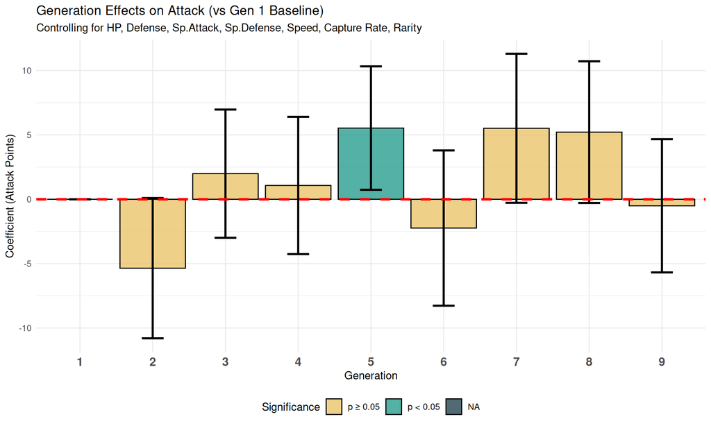

```r
# Visualize generation coefficients with confidence intervals
gen_coefs_plot <- gen_coefs %>%
  mutate(
    ci_lower = estimate - 1.96 * std.error,
    ci_upper = estimate + 1.96 * std.error
  )

# Add Gen 1 reference (coefficient = 0)
gen_coefs_plot <- bind_rows(
  data.frame(term = "gen1", estimate = 0, std.error = NA, statistic = NA,
             p.value = NA, generation = 1, significant = NA,
             direction = "Reference", ci_lower = 0, ci_upper = 0),
  gen_coefs_plot
)

ggplot(gen_coefs_plot, aes(x = factor(generation), y = estimate, fill = significant)) +
  geom_bar(stat = "identity", alpha = 0.8, color = "black") +
  geom_errorbar(aes(ymin = ci_lower, ymax = ci_upper), width = 0.3, linewidth = 1) +
  geom_hline(yintercept = 0, linetype = "dashed", color = "red", linewidth = 1.2) +
  scale_fill_manual(values = c("TRUE" = "#2A9D8F", "FALSE" = "#E9C46A", "NA" = "#264653"),
                    na.value = "#264653",
                    labels = c("TRUE" = "p < 0.05", "FALSE" = "p ≥ 0.05", "NA" = "Reference")) +
  labs(title = "Generation Effects on Attack (vs Gen 1 Baseline)",
       subtitle = "Controlling for HP, Defense, Sp.Attack, Sp.Defense, Speed, Capture Rate, Rarity",
       x = "Generation", y = "Coefficient (Attack Points)",
       fill = "Significance") +
  theme_minimal() +
  theme(legend.position = "bottom",
        axis.text.x = element_text(size = 12, face = "bold"))
```

## 4.3 Likelihood Ratio Test: Does Generation Matter?

```r
# Null model (without generation)
model_null <- glm(attack ~ hp + defense + sp_attack + sp_defense +
                   speed + capture_rate + rarity,
                  data = pokemon, family = gaussian(link = "identity"))

# Likelihood ratio test
lr_test <- anova(model_null, model_primary, test = "Chisq")

cat("═══════════════════════════════════════════════════════════════════
           LIKELIHOOD RATIO TEST: Does Generation Matter?
═══════════════════════════════════════════════════════════════════
H0: Generation has no effect on Attack
H1: At least one generation differs from Generation 1
═══════════════════════════════════════════════════════════════════\n\n")
```

```
## ═══════════════════════════════════════════════════════════════════
##            LIKELIHOOD RATIO TEST: Does Generation Matter?
## ═══════════════════════════════════════════════════════════════════
## H0: Generation has no effect on Attack
## H1: At least one generation differs from Generation 1
## ═══════════════════════════════════════════════════════════════════
```

```r
print(lr_test)
```

```
## Analysis of Deviance Table
##
## Model 1: attack ~ hp + defense + sp_attack + sp_defense + speed + capture_rate +
##     rarity
## Model 2: attack ~ gen + hp + defense + sp_attack + sp_defense + speed +
##     capture_rate + rarity
##   Resid. Df Resid. Dev Df Deviance Pr(>Chi)
## 1      1014     469765
## 2      1006     458220  8    11545 0.001358 **
## ---
## Signif. codes:  0 '***' 0.001 '**' 0.01 '*' 0.05 '.' 0.1 ' ' 1
```

```r
lr_p_value <- lr_test$`Pr(>Chi)`[2]
if(lr_p_value < 0.05) {
  cat(paste0("\n--- Conclusion ---\n",
             "✓ p = ", format.pval(lr_p_value, digits = 4), " < 0.05\n",
             "→ REJECT H0: Generation significantly affects Attack\n"))
} else {
  cat(paste0("\n--- Conclusion ---\n",
             "✗ p = ", format.pval(lr_p_value, digits = 4), " ≥ 0.05\n",
             "→ FAIL TO REJECT H0: No significant generation effect\n"))
}
```

```
##
## --- Conclusion ---
## ✓ p = 0.001358 < 0.05
## → REJECT H0: Generation significantly affects Attack
```

## 4.4 Testing All Combat Stats

```r
# Function to fit GLM and extract generation p-value
fit_and_test <- function(data, response_var) {
  # Build formula with controls (excluding response from controls)
  all_controls <- c("hp", "attack", "defense", "sp_attack", "sp_defense", "speed")
  controls <- setdiff(all_controls, response_var)

  formula_full <- as.formula(paste(response_var, "~ gen +",
                                   paste(controls, collapse = " + "),
                                   "+ capture_rate + rarity"))
  formula_null <- as.formula(paste(response_var, "~",
                                   paste(controls, collapse = " + "),
                                   "+ capture_rate + rarity"))

  model_full <- glm(formula_full, data = data, family = gaussian(link = "identity"))
  model_null <- glm(formula_null, data = data, family = gaussian(link = "identity"))

  # LR test
  lr_test <- anova(model_null, model_full, test = "Chisq")

  # Extract generation coefficients
  gen_coefs <- tidy(model_full) %>%
    filter(str_detect(term, "^gen")) %>%
    dplyr::select(term, estimate, p.value)

  # Count significant positive coefficients
  sig_positive <- sum(gen_coefs$estimate > 0 & gen_coefs$p.value < 0.05)
  sig_negative <- sum(gen_coefs$estimate < 0 & gen_coefs$p.value < 0.05)

  return(list(
    stat = response_var,
    lr_p_value = lr_test$`Pr(>Chi)`[2],
    gen_significant = lr_test$`Pr(>Chi)`[2] < 0.05,
    sig_positive = sig_positive,
    sig_negative = sig_negative,
    coefficients = gen_coefs
  ))
}

# Test all individual stats
all_stats <- c("hp", "attack", "defense", "sp_attack", "sp_defense", "speed")
stat_labels <- c("HP", "Attack", "Defense", "Sp.Attack", "Sp.Defense", "Speed")

results_list <- lapply(all_stats, function(s) fit_and_test(pokemon, s))
names(results_list) <- all_stats

# Summary table
results_summary <- data.frame(
  Stat = stat_labels,
  LR_p_value = sapply(results_list, function(x) x$lr_p_value),
  Generation_Significant = sapply(results_list, function(x) x$gen_significant),
  Sig_Higher_Than_Gen1 = sapply(results_list, function(x) x$sig_positive),
  Sig_Lower_Than_Gen1 = sapply(results_list, function(x) x$sig_negative)
)

cat("═══════════════════════════════════════════════════════════════════
           GLM RESULTS: ALL COMBAT STATS
═══════════════════════════════════════════════════════════════════
Likelihood Ratio Test: H0 = Generation has no effect
═══════════════════════════════════════════════════════════════════\n\n")
```

```
## ═══════════════════════════════════════════════════════════════════
##            GLM RESULTS: ALL COMBAT STATS
## ═══════════════════════════════════════════════════════════════════
## Likelihood Ratio Test: H0 = Generation has no effect
## ═══════════════════════════════════════════════════════════════════
```

```r
results_summary$LR_p_value <- format.pval(results_summary$LR_p_value, digits = 4)
print(results_summary, row.names = FALSE)
```

```
##        Stat LR_p_value Generation_Significant Sig_Higher_Than_Gen1
##          HP  0.0277368                   TRUE                    1
##      Attack  0.0013580                   TRUE                    1
##     Defense  0.5468181                  FALSE                    0
##   Sp.Attack  0.3018472                  FALSE                    0
##  Sp.Defense  0.8089924                  FALSE                    0
##       Speed  0.0001874                   TRUE                    0
##  Sig_Lower_Than_Gen1
##                    0
##                    0
##                    0
##                    1
##                    0
##                    3
```

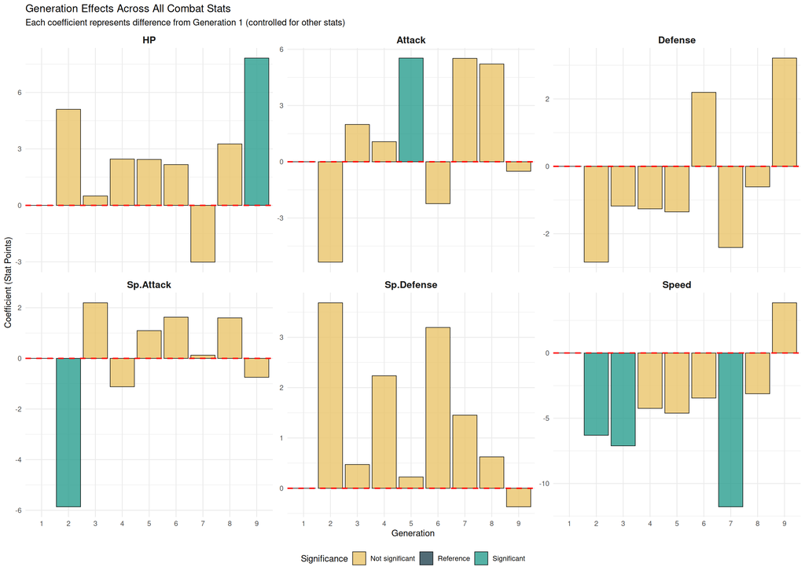

```r
# Extract all coefficients for visualization
all_coefs <- bind_rows(lapply(names(results_list), function(stat) {
  results_list[[stat]]$coefficients %>%
    mutate(stat = stat,
           generation = as.numeric(str_extract(term, "\\d+")))
}))

# Add reference level
reference_rows <- data.frame(
  term = rep("gen1", 6),
  estimate = 0,
  p.value = NA,
  stat = all_stats,
  generation = 1
)

all_coefs_complete <- bind_rows(reference_rows, all_coefs) %>%
  mutate(significant = ifelse(is.na(p.value), "Reference",
                              ifelse(p.value < 0.05, "Significant", "Not significant")),
         stat_label = factor(stat, levels = all_stats, labels = stat_labels))

# Faceted coefficient plot
ggplot(all_coefs_complete, aes(x = factor(generation), y = estimate, fill = significant)) +
  geom_bar(stat = "identity", alpha = 0.8, color = "black", linewidth = 0.3) +
  geom_hline(yintercept = 0, linetype = "dashed", color = "red", linewidth = 0.8) +
  facet_wrap(~stat_label, scales = "free_y", ncol = 3) +
  scale_fill_manual(values = c("Significant" = "#2A9D8F",
                               "Not significant" = "#E9C46A",
                               "Reference" = "#264653")) +
  labs(title = "Generation Effects Across All Combat Stats",
       subtitle = "Each coefficient represents difference from Generation 1 (controlled for other stats)",
       x = "Generation", y = "Coefficient (Stat Points)",
       fill = "Significance") +
  theme_minimal() +
  theme(legend.position = "bottom",
        strip.text = element_text(size = 12, face = "bold"))
```

## 4.5 Jonckheere-Terpstra Trend Test

Tests for monotonic trend across ordered generations:

```r
# Jonckheere-Terpstra test for each stat
jt_results <- data.frame(
  Stat = character(),
  JT_Statistic = numeric(),
  p_value = numeric(),
  Direction = character(),
  stringsAsFactors = FALSE
)

for(i in seq_along(all_stats)) {
  stat_var <- all_stats[i]
  stat_label <- stat_labels[i]

  # Run JT test
  jt_test <- JonckheereTerpstraTest(
    pokemon[[stat_var]] ~ pokemon$gen,
    alternative = "increasing"
  )

  jt_results <- rbind(jt_results, data.frame(
    Stat = stat_label,
    JT_Statistic = jt_test$statistic,
    p_value = jt_test$p.value,
    Direction = ifelse(jt_test$p.value < 0.05, "Increasing trend", "No significant trend")
  ))
}

cat("═══════════════════════════════════════════════════════════════════
           JONCKHEERE-TERPSTRA TREND TEST
═══════════════════════════════════════════════════════════════════
H0: No monotonic trend across generations
H1: Increasing trend (later generations have higher stats)
═══════════════════════════════════════════════════════════════════\n\n")
```

```
## ═══════════════════════════════════════════════════════════════════
##            JONCKHEERE-TERPSTRA TREND TEST
## ═══════════════════════════════════════════════════════════════════
## H0: No monotonic trend across generations
## H1: Increasing trend (later generations have higher stats)
## ═══════════════════════════════════════════════════════════════════
```

```r
jt_results$p_value <- format.pval(jt_results$p_value, digits = 4)
print(jt_results, row.names = FALSE)
```

```
##        Stat JT_Statistic   p_value        Direction
##          HP     254979.5 6.654e-06 Increasing trend
##      Attack     253582.5 2.088e-05 Increasing trend
##     Defense     250828.0 0.0001655 Increasing trend
##   Sp.Attack     242068.0 0.0241308 Increasing trend
##  Sp.Defense     243499.0 0.0125836 Increasing trend
##       Speed     241709.0 0.0281385 Increasing trend
```

## 4.6 Robustness Check: Gamma GLM

```r
# Gamma GLM with log link for Attack
model_gamma <- glm(attack ~ gen + hp + defense + sp_attack + sp_defense +
                    speed + capture_rate + rarity,
                   data = pokemon, family = Gamma(link = "log"))

cat("═══════════════════════════════════════════════════════════════════
           ROBUSTNESS CHECK: Gamma GLM (Log Link)
═══════════════════════════════════════════════════════════════════\n\n")
```

```
## ═══════════════════════════════════════════════════════════════════
##            ROBUSTNESS CHECK: Gamma GLM (Log Link)
## ═══════════════════════════════════════════════════════════════════
```

```r
# Extract generation coefficients
gamma_coefs <- tidy(model_gamma) %>%
  filter(str_detect(term, "^gen")) %>%
  mutate(
    generation = as.numeric(str_extract(term, "\\d+")),
    # Convert to percentage change
    pct_change = (exp(estimate) - 1) * 100,
    significant = p.value < 0.05
  )

gamma_display <- gamma_coefs %>%
  dplyr::select(generation, estimate, pct_change, p.value, significant) %>%
  mutate(across(c(estimate, pct_change), ~round(., 3)),
         p.value = format.pval(p.value, digits = 3))

cat("Coefficients are on log scale. exp(coef) - 1 = % change from Gen 1\n\n")
```

```
## Coefficients are on log scale. exp(coef) - 1 = % change from Gen 1
```

```r
print(gamma_display, row.names = FALSE)
```

```
## # A tibble: 8 × 5
##   generation estimate pct_change p.value significant
##        <dbl>    <dbl>      <dbl> <chr>   <lgl>
## 1          2   -0.092     -8.83  0.0148  TRUE
## 2          3    0.009      0.909 0.7938  FALSE
## 3          4   -0.012     -1.21  0.7420  FALSE
## 4          5    0.056      5.80  0.0909  FALSE
## 5          6   -0.043     -4.23  0.3029  FALSE
## 6          7    0.057      5.82  0.1603  FALSE
## 7          8    0.03       3.05  0.4319  FALSE
## 8          9   -0.035     -3.45  0.3296  FALSE
```

```r
# Compare Gaussian vs Gamma
cat("\n═══════════════════════════════════════════════════════════════════
           COMPARISON: Gaussian vs Gamma Models
═══════════════════════════════════════════════════════════════════\n\n")
```

```
##
## ═══════════════════════════════════════════════════════════════════
##            COMPARISON: Gaussian vs Gamma Models
## ═══════════════════════════════════════════════════════════════════
```

```r
comparison_models <- data.frame(
  Model = c("Gaussian (Identity)", "Gamma (Log)"),
  AIC = c(AIC(model_primary), AIC(model_gamma)),
  BIC = c(BIC(model_primary), BIC(model_gamma))
)
comparison_models[, c("AIC", "BIC")] <- round(comparison_models[, c("AIC", "BIC")], 2)
print(comparison_models, row.names = FALSE)
```

```
##                Model     AIC     BIC
##  Gaussian (Identity) 9194.11 9287.80
##          Gamma (Log) 9279.44 9373.14
```

```r
cat("\nLower AIC/BIC indicates better fit.\n")
```

```
##
## Lower AIC/BIC indicates better fit.
```

## 4.7 Robustness Check: Normal-Only Pokémon

```r
# Fit model on Normal-rarity Pokémon only
model_normal <- glm(attack ~ gen + hp + defense + sp_attack + sp_defense +
                     speed + capture_rate,
                    data = pokemon_normal, family = gaussian(link = "identity"))

cat(paste0("═══════════════════════════════════════════════════════════════════
           ROBUSTNESS CHECK: Normal-Rarity Pokémon Only
           (Excluding Legendaries, Sub-legendaries, Mythicals)
═══════════════════════════════════════════════════════════════════
Sample size: ", nrow(pokemon_normal), " Pokémon\n\n"))
```

```
## ═══════════════════════════════════════════════════════════════════
##            ROBUSTNESS CHECK: Normal-Rarity Pokémon Only
##            (Excluding Legendaries, Sub-legendaries, Mythicals)
## ═══════════════════════════════════════════════════════════════════
## Sample size: 934 Pokémon
```

```r
# Extract generation coefficients
normal_coefs <- tidy(model_normal) %>%
  filter(str_detect(term, "^gen")) %>%
  mutate(
    generation = as.numeric(str_extract(term, "\\d+")),
    significant = p.value < 0.05
  )

normal_display <- normal_coefs %>%
  dplyr::select(generation, estimate, std.error, p.value, significant) %>%
  mutate(across(c(estimate, std.error), ~round(., 3)),
         p.value = format.pval(p.value, digits = 3))

print(normal_display, row.names = FALSE)
```

```
## # A tibble: 8 × 5
##   generation estimate std.error p.value significant
##        <dbl>    <dbl>     <dbl> <chr>   <lgl>
## 1          2   -6.05       2.82 0.0325  TRUE
## 2          3    1.54       2.59 0.5524  FALSE
## 3          4    1.19       2.82 0.6726  FALSE
## 4          5    5.12       2.50 0.0404  TRUE
## 5          6   -3.76       3.14 0.2319  FALSE
## 6          7    5.84       3.23 0.0707  FALSE
## 7          8    4.82       2.85 0.0917  FALSE
## 8          9   -0.836      2.66 0.7535  FALSE
```

```r
# LR test for Normal-only
model_normal_null <- glm(attack ~ hp + defense + sp_attack + sp_defense +
                          speed + capture_rate,
                         data = pokemon_normal, family = gaussian(link = "identity"))

lr_normal <- anova(model_normal_null, model_normal, test = "Chisq")

if(lr_normal$`Pr(>Chi)`[2] < 0.05) {
  cat(paste0("\n--- Likelihood Ratio Test (Normal-Only) ---\n",
             "p-value: ", format.pval(lr_normal$`Pr(>Chi)`[2], digits = 4), "\n",
             "→ Generation significantly affects Attack even among Normal-rarity Pokémon\n"))
} else {
  cat(paste0("\n--- Likelihood Ratio Test (Normal-Only) ---\n",
             "p-value: ", format.pval(lr_normal$`Pr(>Chi)`[2], digits = 4), "\n",
             "→ Generation effect not significant among Normal-rarity Pokémon\n"))
}
```

```
##
## --- Likelihood Ratio Test (Normal-Only) ---
## p-value: 0.0008571
## → Generation significantly affects Attack even among Normal-rarity Pokémon
```

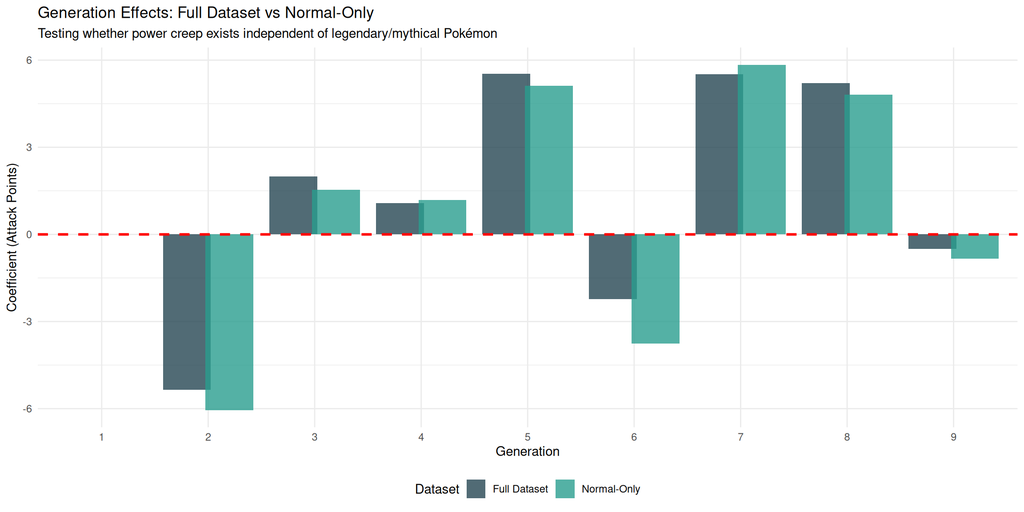

```r
# Compare coefficients: Full dataset vs Normal-only
coef_comparison <- gen_coefs %>%
  dplyr::select(generation, estimate, significant) %>%
  rename(Full_Estimate = estimate, Full_Sig = significant) %>%
  left_join(
    normal_coefs %>%
      dplyr::select(generation, estimate, significant) %>%
      rename(Normal_Estimate = estimate, Normal_Sig = significant),
    by = "generation"
  )

# Add Gen 1 reference
coef_comparison <- bind_rows(
  data.frame(generation = 1, Full_Estimate = 0, Full_Sig = NA,
             Normal_Estimate = 0, Normal_Sig = NA),
  coef_comparison
)

# Reshape for plotting
coef_long <- coef_comparison %>%
  pivot_longer(cols = c(Full_Estimate, Normal_Estimate),
               names_to = "Dataset", values_to = "Coefficient") %>%
  mutate(Dataset = ifelse(Dataset == "Full_Estimate", "Full Dataset", "Normal-Only"))

ggplot(coef_long, aes(x = factor(generation), y = Coefficient, fill = Dataset)) +
  geom_bar(stat = "identity", position = position_dodge(width = 0.8), alpha = 0.8) +
  geom_hline(yintercept = 0, linetype = "dashed", color = "red", linewidth = 1) +
  scale_fill_manual(values = c("Full Dataset" = "#264653", "Normal-Only" = "#2A9D8F")) +
  labs(title = "Generation Effects: Full Dataset vs Normal-Only",
       subtitle = "Testing whether power creep exists independent of legendary/mythical Pokémon",
       x = "Generation", y = "Coefficient (Attack Points)",
       fill = "Dataset") +
  theme_minimal() +
  theme(legend.position = "bottom")
```

## 4.8 Effect Size Analysis

```r
# Calculate Cohen's d for each generation vs Gen 1
gen1_attack <- pokemon$attack[pokemon$gen == "1"]

cohens_d <- data.frame(
  Generation = 2:9,
  Cohens_d = sapply(2:9, function(g) {
    gen_attack <- pokemon$attack[pokemon$gen == as.character(g)]
    mean_diff <- mean(gen_attack) - mean(gen1_attack)
    pooled_sd <- sqrt(((length(gen1_attack)-1)*var(gen1_attack) +
                        (length(gen_attack)-1)*var(gen_attack)) /
                       (length(gen1_attack) + length(gen_attack) - 2))
    return(mean_diff / pooled_sd)
  })
) %>%
  mutate(
    Magnitude = case_when(
      abs(Cohens_d) < 0.2 ~ "Negligible",
      abs(Cohens_d) < 0.5 ~ "Small",
      abs(Cohens_d) < 0.8 ~ "Medium",
      TRUE ~ "Large"
    )
  )

cat("═══════════════════════════════════════════════════════════════════
           EFFECT SIZE ANALYSIS: Cohen's d
═══════════════════════════════════════════════════════════════════
Cohen's d thresholds: |d| < 0.2 = negligible, 0.2-0.5 = small,
                      0.5-0.8 = medium, > 0.8 = large
═══════════════════════════════════════════════════════════════════\n\n")
```

```
## ═══════════════════════════════════════════════════════════════════
##            EFFECT SIZE ANALYSIS: Cohen's d
## ═══════════════════════════════════════════════════════════════════
## Cohen's d thresholds: |d| < 0.2 = negligible, 0.2-0.5 = small,
##                       0.5-0.8 = medium, > 0.8 = large
## ═══════════════════════════════════════════════════════════════════
```

```r
cohens_d$Cohens_d <- round(cohens_d$Cohens_d, 3)
print(cohens_d, row.names = FALSE)
```

```
##  Generation Cohens_d  Magnitude
##           2   -0.170 Negligible
##           3    0.007 Negligible
##           4    0.256      Small
##           5    0.289      Small
##           6   -0.016 Negligible
##           7    0.407      Small
##           8    0.349      Small
##           9    0.341      Small
```

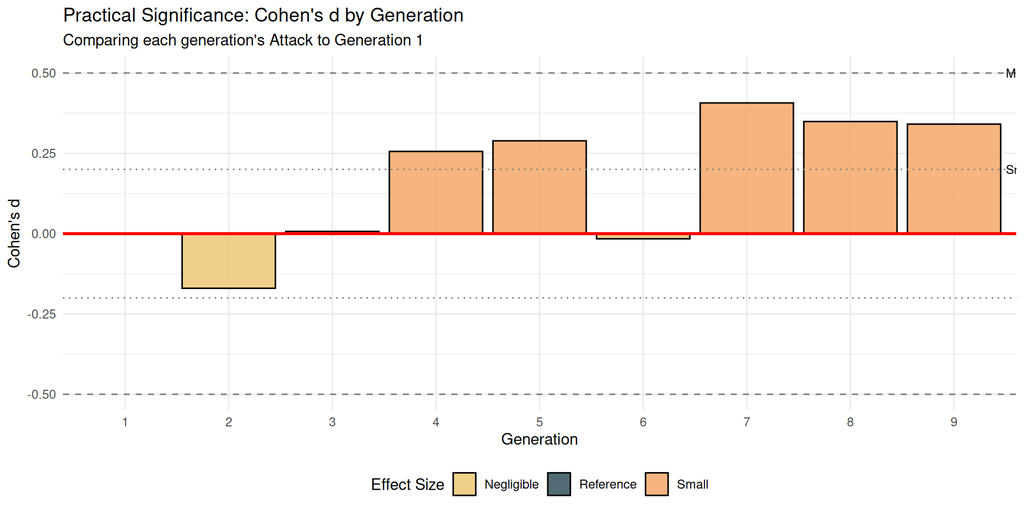

```r
# Add Gen 1 reference
cohens_d_plot <- bind_rows(
  data.frame(Generation = 1, Cohens_d = 0, Magnitude = "Reference"),
  cohens_d
)

ggplot(cohens_d_plot, aes(x = factor(Generation), y = Cohens_d, fill = Magnitude)) +
  geom_bar(stat = "identity", alpha = 0.8, color = "black") +
  geom_hline(yintercept = c(-0.2, 0.2), linetype = "dotted", color = "gray50") +
  geom_hline(yintercept = c(-0.5, 0.5), linetype = "dashed", color = "gray50") +
  geom_hline(yintercept = 0, color = "red", linewidth = 1) +
  scale_fill_manual(values = c("Reference" = "#264653", "Negligible" = "#E9C46A",
                               "Small" = "#F4A261", "Medium" = "#E76F51",
                               "Large" = "#9B5DE5")) +
  annotate("text", x = 9.5, y = 0.2, label = "Small", size = 3, hjust = 0) +
  annotate("text", x = 9.5, y = 0.5, label = "Medium", size = 3, hjust = 0) +
  labs(title = "Practical Significance: Cohen's d by Generation",
       subtitle = "Comparing each generation's Attack to Generation 1",
       x = "Generation", y = "Cohen's d",
       fill = "Effect Size") +
  theme_minimal() +
  theme(legend.position = "bottom")
```